# Disaster Relief Project: Part I

Rehan Merchant rm2bt

May 10, 2021

**SYS 6018 | Spring 2021 | University of Virginia**

# 1 Introduction

In 2010 an earthquake hit Haiti and caused a lot of destruction in the country. Many of the residents of Haiti were displaced and cut off from food and water sources. Communication and roads were also effected by the earthquake. Because of this, officials had trouble locating displaced citizens and getting aid to them. In order to solve this problem, an aircraft was flown above to collect images of the ground. This would help identify shelters that have been created by displaced individuals. Because, this was time sensitive, the images were ran through data mining algorithms to search the images quickly and effectively in order to locate those displaced individuals. We are attempting to simulate what happened in 2010 by testing different models on the imagery collected from the disaster in 2010. After testing each of these models, we will compare and come up with which model would produce the most accurate results in a timely manner.

# 2 Training Data / EDA

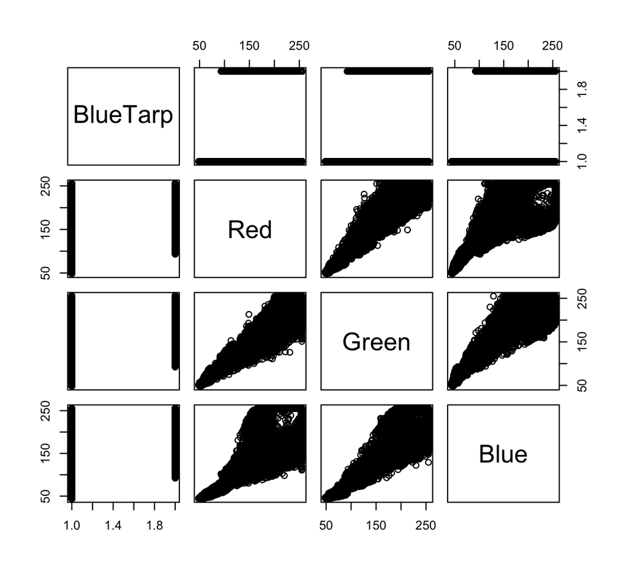

```r
# Load Required Packages
library(tidyverse)
library(caret)
library(MASS)
library(boot)
library(ggplot2)
library(dplyr)
library(stringr)
library(GGally)
library(ROCR)
library(MLeval)
library(pROC)
library(glmnet)
library(yardstick)
#load data
data <- read.csv('HaitiPixels.csv')
attach(data)
data$BlueTarp <- str_detect(Class,"Blue Tarp")
data$BlueTarp <- factor(data$BlueTarp)
pairs(BlueTarp~ Red + Green + Blue, data = data)
```

```r
#positive correlation between the variables but none between BlueTarp
#made blue tarp a separate variable and made it a binary 2 class variable
```

# 3 Model Training

## 3.1 Set-up

```r
set.seed(1)
index <- createDataPartition(y = data$BlueTarp, p =0.5, list = F)
train <- data[index,]
test <- data[-index,]
```

## 3.2 Logistic Regression

```r
glm.fits <- glm(BlueTarp ~ Red + Green + Blue, family = 'binomial', data = train)
summary(glm.fits)
```

```
#>
#> Call:
#> glm(formula = BlueTarp ~ Red + Green + Blue, family = "binomial",
#>     data = train)
#>
#> Deviance Residuals:
#>     Min       1Q   Median       3Q      Max
#> -3.4985  -0.0190  -0.0013   0.0000   3.7202
#>
#> Coefficients:
#>             Estimate Std. Error z value Pr(>|z|)
#> (Intercept)  0.38914    0.25867   1.504    0.132
#> Red         -0.28111    0.01870 -15.031   <2e-16 ***
#> Green       -0.21076    0.01918 -10.990   <2e-16 ***
#> Blue         0.48492    0.02257  21.486   <2e-16 ***
#> ---
#> Signif. codes:  0 '***' 0.001 '**' 0.01 '*' 0.05 '.' 0.1 ' ' 1
#>
#> (Dispersion parameter for binomial family taken to be 1)
#>
#>     Null deviance: 8950.83  on 31620  degrees of freedom
#> Residual deviance:  896.66  on 31617  degrees of freedom
#> AIC: 904.66
#>
#> Number of Fisher Scoring iterations: 12
```

```r
#all predictors are significant except intercept

#crossval
ctrl <- trainControl(method='cv',
                     number=10,
                     savePredictions = T)
glmmod <- train(BlueTarp~ .-Class,
                data=train,
                method='glm',
                trControl=ctrl)
glmmod$results
```

```
#>   parameter  Accuracy     Kappa  AccuracySD    KappaSD
#> 1      none 0.9951615 0.9181186 0.001273883 0.02250946
```

```r
#predict
glm.predict <- predict(glm.fits, newdata = test, type="response")

#confusionMatrix

confusionMatrix(data = as.factor(glm.predict>=0.5), reference = test$BlueTarp)
```

```
#> Confusion Matrix and Statistics
#>
#>           Reference
#> Prediction FALSE  TRUE
#>      FALSE 30576   104
#>      TRUE     33   907
#>
#>                Accuracy : 0.9957
#>                  95% CI : (0.9949, 0.9964)
#>     No Information Rate : 0.968
#>     P-Value [Acc > NIR] : < 2.2e-16
#>
#>                   Kappa : 0.9275
#>
#>  Mcnemar's Test P-Value : 2.224e-09
#>
#>             Sensitivity : 0.9989
#>             Specificity : 0.8971
#>          Pos Pred Value : 0.9966
#>          Neg Pred Value : 0.9649
#>              Prevalence : 0.9680
#>          Detection Rate : 0.9670
#>    Detection Prevalence : 0.9703
#>       Balanced Accuracy : 0.9480
#>
#>        'Positive' Class : FALSE
#>
```

```r
#proc
my_roc_glm <- roc(test$BlueTarp,glm.predict)
```

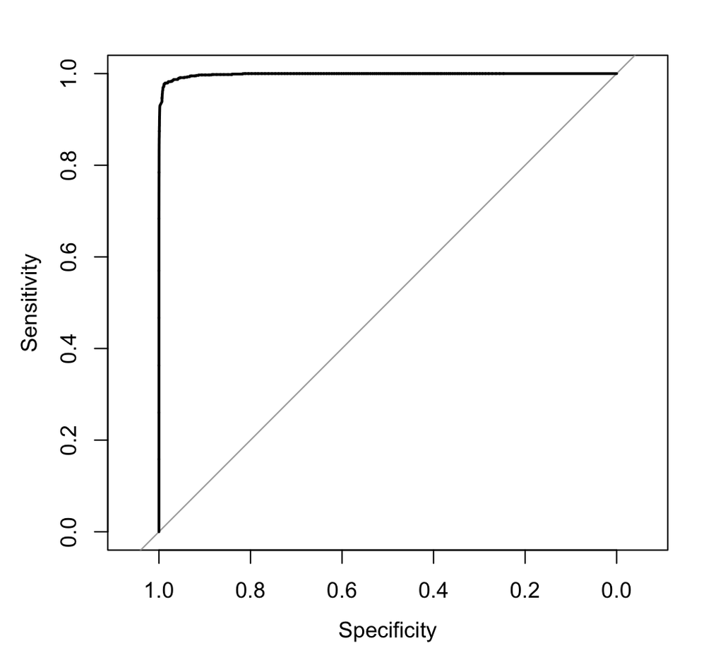

```r
plot(my_roc_glm)
```

```r
#performance values
auc.glm <- auc(my_roc_glm)
coords(my_roc_glm,'best',ret = 'threshold')
```

```
#>   threshold
#> 1 0.0571714
```

```r
coords(my_roc_glm,'best', ret = 'accuracy')
```

```
#>            accuracy
#> threshold 0.9886781
```

```r
coords(my_roc_glm,'best', ret = 'tpr')
```

```
#>                 tpr
#> threshold 0.9772502
```

```r
coords(my_roc_glm,'best', ret = 'fpr')
```

```
#>                  fpr
#> threshold 0.01094449
```

```r
coords(my_roc_glm,'best', ret = 'precision')
```

```
#>           precision
#> threshold 0.7467876
```

## 3.3 LDA

```r
lda.fits <- lda(BlueTarp ~ Red + Green + Blue, family = 'binomial', data=train)

#crossval
set.seed(105)
ctrl <- trainControl(method='cv',
                     number=10,
                     savePredictions = T)
ldamod <- train(BlueTarp~ .-Class,
                data=train,
                method='lda',
                trControl=ctrl)
ldamod$results
```

```
#>   parameter  Accuracy     Kappa  AccuracySD    KappaSD
#> 1      none 0.9831441 0.7421268 0.002124413 0.02897641
```

```r
#predict
lda.predict <- predict(lda.fits, newdata = test, family = 'binomial')

#confusionMatrix
confusionMatrix(data = lda.predict$class, reference = test$BlueTarp)
```

```
#> Confusion Matrix and Statistics
#>
#>           Reference
#> Prediction FALSE  TRUE
#>      FALSE 30319   193
#>      TRUE    290   818
#>
#>                Accuracy : 0.9847
#>                  95% CI : (0.9833, 0.986)
#>     No Information Rate : 0.968
#>     P-Value [Acc > NIR] : < 2.2e-16
#>
#>                   Kappa : 0.7642
#>
#>  Mcnemar's Test P-Value : 1.253e-05
#>
#>             Sensitivity : 0.9905
#>             Specificity : 0.8091
#>          Pos Pred Value : 0.9937
#>          Neg Pred Value : 0.7383
#>              Prevalence : 0.9680
#>          Detection Rate : 0.9589
#>    Detection Prevalence : 0.9650
#>       Balanced Accuracy : 0.8998
#>
#>        'Positive' Class : FALSE
#>
```

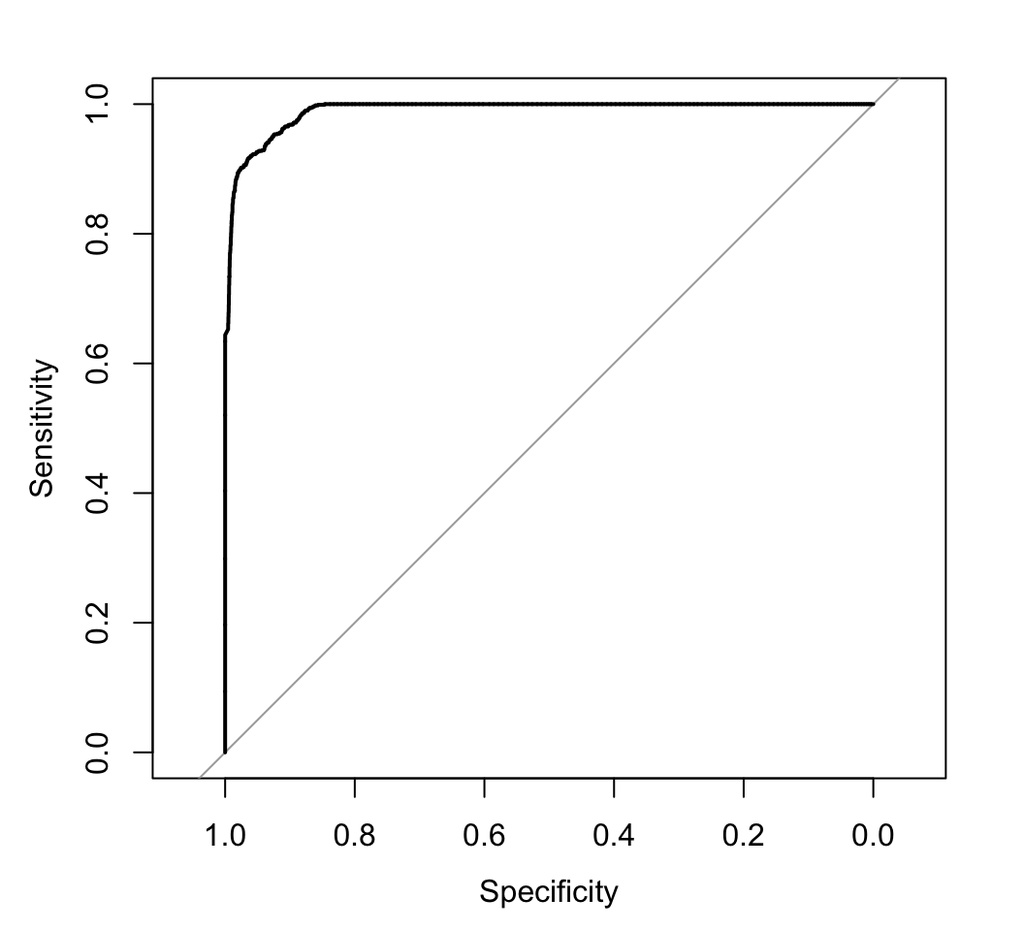

```r
#roc curve
#proc
my_roc_lda <- roc(test$BlueTarp,lda.predict$x)
plot(my_roc_lda)
```

```r
#performance table values
auc(my_roc_lda)
```

```
#> Area under the curve: 0.9898
```

```r
coords(my_roc_lda,'best', ret = 'threshold')
```

```
#>   threshold
#> 1   1.66575
```

```r
coords(my_roc_lda,'best', ret = 'accuracy')
```

```
#>            accuracy
#> threshold 0.9633776
```

```r
coords(my_roc_lda,'best', ret = 'tpr')
```

```
#>                 tpr
#> threshold 0.9159248
```

```r
coords(my_roc_lda,'best', ret = 'fpr')
```

```
#>                  fpr
#> threshold 0.03505505
```

```r
coords(my_roc_lda,'best', ret = 'precision')
```

```
#>           precision
#> threshold 0.4632316
```

## 3.4 QDA

```r
qda.fits <- qda(BlueTarp ~ Red + Green +Blue, family = 'binomial', data=train)

#crossval
set.seed(106)
ctrl <- trainControl(method='cv',
                     number=10,
                     savePredictions = T)
qdamod <- train(BlueTarp~ .-Class,
                data=train,
                method='qda',
                trControl=ctrl)
qdamod$results
```

```
#>   parameter  Accuracy     Kappa  AccuracySD    KappaSD
#> 1      none 0.9942127 0.8976041 0.001874326 0.03559099
```

```r
#predict
qda.predict <- predict(qda.fits, newdata = test, family = 'binomial')

#confusion matrix
confusionMatrix(reference = test$BlueTarp, data = qda.predict$class)
```

```
#> Confusion Matrix and Statistics
#>
#>           Reference
#> Prediction FALSE  TRUE
#>      FALSE 30600   152
#>      TRUE      9   859
#>
#>                Accuracy : 0.9949
#>                  95% CI : (0.9941, 0.9957)
#>     No Information Rate : 0.968
#>     P-Value [Acc > NIR] : < 2.2e-16
#>
#>                   Kappa : 0.9117
#>
#>  Mcnemar's Test P-Value : < 2.2e-16
#>
#>             Sensitivity : 0.9997
#>             Specificity : 0.8497
#>          Pos Pred Value : 0.9951
#>          Neg Pred Value : 0.9896
#>              Prevalence : 0.9680
#>          Detection Rate : 0.9677
#>    Detection Prevalence : 0.9725
#>       Balanced Accuracy : 0.9247
#>
#>        'Positive' Class : FALSE
#>
```

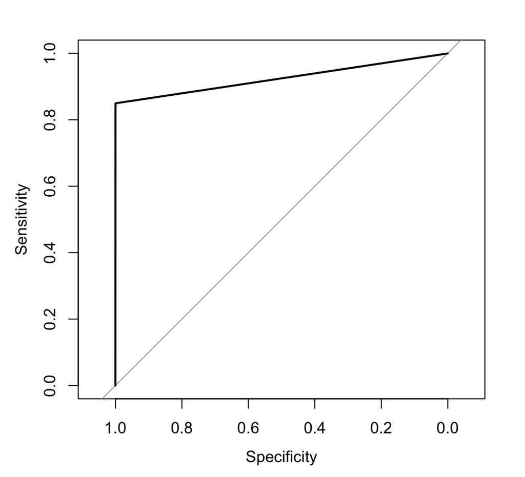

```r
#roc curve
#proc
my_roc_qda <- roc(test$BlueTarp,as.numeric(qda.predict$class))
plot(my_roc_qda)
```

```r
#performance table values
auc(my_roc_qda)
```

```
#> Area under the curve: 0.9247
```

```r
coords(my_roc_qda,'best',ret = 'threshold')
```

```
#>   threshold
#> 1       1.5
```

```r
coords(my_roc_qda,'best', ret = 'accuracy')
```

```
#>            accuracy
#> threshold 0.9949083
```

```r
coords(my_roc_qda,'best', ret = 'tpr')
```

```
#>                 tpr
#> threshold 0.8496538
```

```r
coords(my_roc_qda,'best', ret = 'fpr')
```

```
#>                    fpr
#> threshold 0.0002940312
```

```r
coords(my_roc_qda,'best', ret = 'precision')
```

```
#>           precision
#> threshold 0.9896313
```

## 3.5 KNN

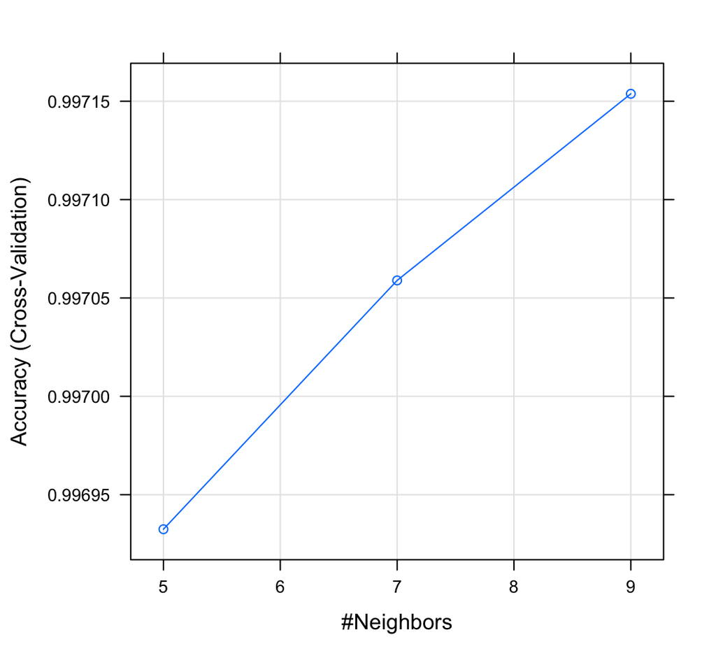

```r
knn.fits <- knn3(BlueTarp ~ Red + Green +Blue,data = train)

#cross val
ctrl <- trainControl(method = 'cv', number = 10, savePredictions = T)
knnmod <- train(BlueTarp~ Red + Green + Blue, method = 'knn', data = train, trControl = ctrl)
plot(knnmod)
```

```r
#best k val
knnBestTune <- knnmod$bestTune

knn.fits.besttune <- knn3(BlueTarp ~ Red + Green +Blue,data = train, k = knnBestTune)

#predict
knn.predict <- predict(knn.fits.besttune, newdata = test, type = 'class')


#confusion matrix
confusionMatrix(table(predicted = knn.predict,
                      reference = test$BlueTarp))
```

```
#> Confusion Matrix and Statistics
#>
#>          reference
#> predicted FALSE  TRUE
#>     FALSE 30551    45
#>     TRUE     58   966
#>
#>                Accuracy : 0.9967
#>                  95% CI : (0.9961, 0.9973)
#>     No Information Rate : 0.968
#>     P-Value [Acc > NIR] : <2e-16
#>
#>                   Kappa : 0.9477
#>
#>  Mcnemar's Test P-Value : 0.237
#>
#>             Sensitivity : 0.9981
#>             Specificity : 0.9555
#>          Pos Pred Value : 0.9985
#>          Neg Pred Value : 0.9434
#>              Prevalence : 0.9680
#>          Detection Rate : 0.9662
#>    Detection Prevalence : 0.9676
#>       Balanced Accuracy : 0.9768
#>
#>        'Positive' Class : FALSE
#>
```

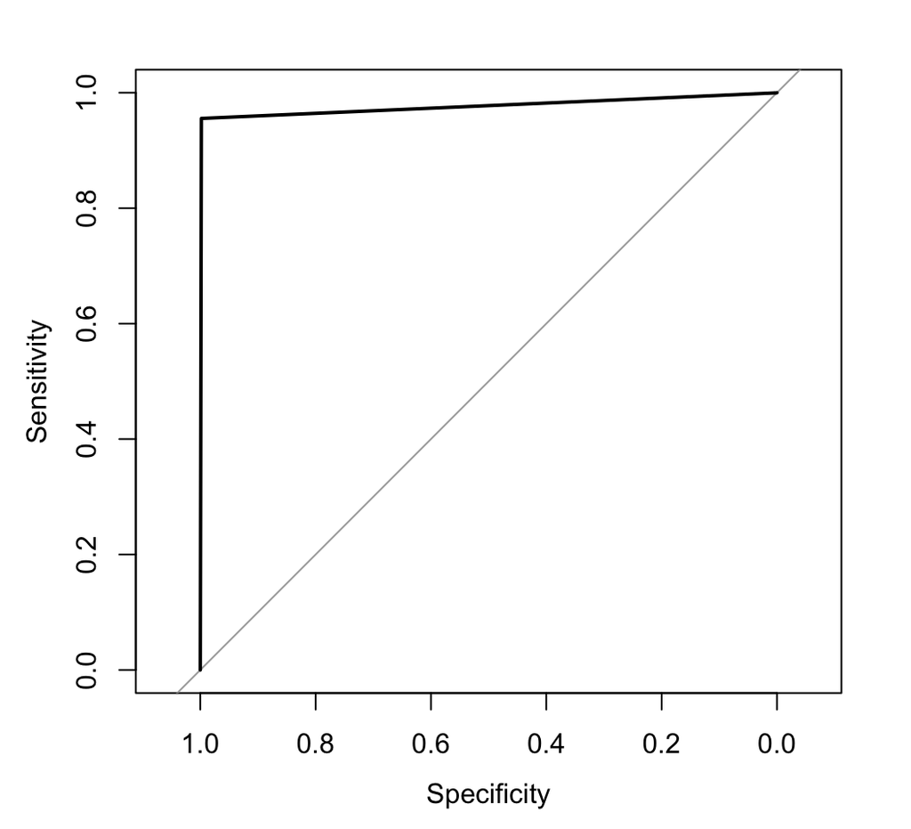

```r
#roc curve
#proc
my_roc_knn <- roc(test$BlueTarp,as.numeric(knn.predict))
plot(my_roc_knn)
```

```r
#performance table values
auc(my_roc_knn)
```

```
#> Area under the curve: 0.9768
```

```r
coords(my_roc_knn,'best',ret = 'threshold')
```

```
#>   threshold
#> 1       1.5
```

```r
coords(my_roc_knn,'best', ret = 'accuracy')
```

```
#>            accuracy
#> threshold 0.9967426
```

```r
coords(my_roc_knn,'best', ret = 'tpr')
```

```
#>                 tpr
#> threshold 0.9554896
```

```r
coords(my_roc_knn,'best', ret = 'fpr')
```

```
#>                   fpr
#> threshold 0.001894868
```

```r
coords(my_roc_knn,'best', ret = 'precision')
```

```
#>           precision
#> threshold 0.9433594
```

## 3.6 Penalized Logistic Regression (ElasticNet)

```r
#Elastic net
fmla <- lm(formula(BlueTarp~.-Class),
             data=train)
#design matrix
x=model.matrix(fmla, data = train)[,-1]
y= train$BlueTarp

#crossval
set.seed(123)
model.elastic <- train(
  BlueTarp ~ Red + Green +Blue, data = train, method = 'glmnet', trControl = trainControl('cv', number = 10), tuneLength = 10
)
#best Tuning value
model.elastic$bestTune
```

```
#>    alpha       lambda
#> 81   0.9 1.901767e-05
```

```r
coef(model.elastic$finalModel, model.elastic$bestTune$lambda)
```

```
#> 4 x 1 sparse Matrix of class "dgCMatrix"
#>                      1
#> (Intercept) -0.3946678
#> Red         -0.2320374
#> Green       -0.1620448
#> Blue         0.3908594
```

```r
#test
test.elastic <- model.matrix(fmla, data=test)[,-1]
predictions.elastic <- predict(model.elastic,newdata = test)

#confusion matrix
confusionMatrix(table(predicted = predictions.elastic,
                      reference = test$BlueTarp))
```

```
#> Confusion Matrix and Statistics
#>
#>          reference
#> predicted FALSE  TRUE
#>     FALSE 30582   120
#>     TRUE     27   891
#>
#>                Accuracy : 0.9954
#>                  95% CI : (0.9945, 0.9961)
#>     No Information Rate : 0.968
#>     P-Value [Acc > NIR] : < 2.2e-16
#>
#>                   Kappa : 0.9214
#>
#>  Mcnemar's Test P-Value : 3.248e-14
#>
#>             Sensitivity : 0.9991
#>             Specificity : 0.8813
#>          Pos Pred Value : 0.9961
#>          Neg Pred Value : 0.9706
#>              Prevalence : 0.9680
#>          Detection Rate : 0.9672
#>    Detection Prevalence : 0.9710
#>       Balanced Accuracy : 0.9402
#>
#>        'Positive' Class : FALSE
#>
```

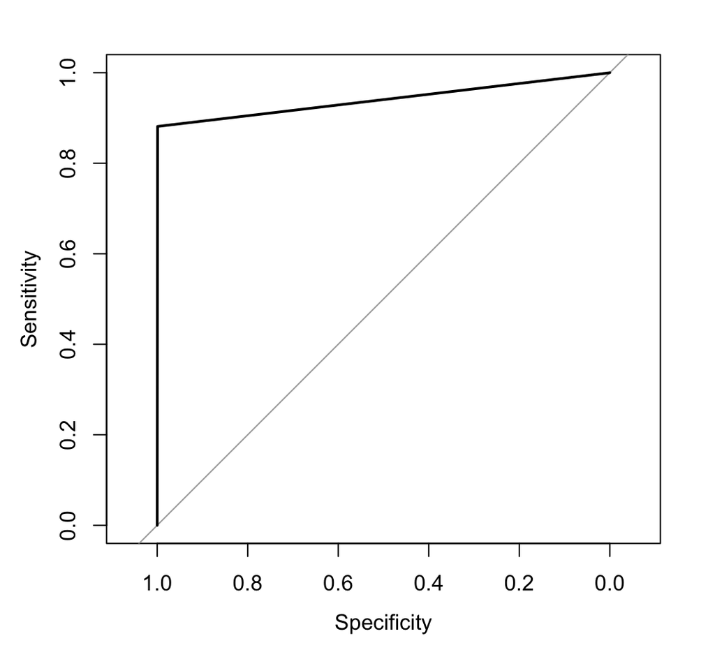

```r
#roc curve
#proc
my_roc_elastic <- roc(test$BlueTarp,as.numeric(predictions.elastic))
plot(my_roc_elastic)
```

```r
#performance table values
auc(my_roc_elastic)
```

```
#> Area under the curve: 0.9402
```

```r
coords(my_roc_elastic,'best',ret = 'threshold')
```

```
#>   threshold
#> 1       1.5
```

```r
coords(my_roc_elastic,'best', ret = 'accuracy')
```

```
#>           accuracy
#> threshold 0.995351
```

```r
coords(my_roc_elastic,'best', ret = 'tpr')
```

```
#>                 tpr
#> threshold 0.8813056
```

```r
coords(my_roc_elastic,'best', ret = 'fpr')
```

```
#>                    fpr
#> threshold 0.0008820935
```

```r
coords(my_roc_elastic,'best', ret = 'precision')
```

```
#>           precision
#> threshold 0.9705882
```

## 3.7 Random Forest (Part 2)

```r
library(randomForest)
rf.data <- randomForest(BlueTarp~ Red + Green + Blue, data = train, mtry=3, importance = TRUE)
rf.data
```

```
#>
#> Call:
#>  randomForest(formula = BlueTarp ~ Red + Green + Blue, data = train,      mtry = 3, importance = TRUE)
#>                Type of random forest: classification
#>                      Number of trees: 500
#> No. of variables tried at each split: 3
#>
#>         OOB estimate of  error rate: 0.35%
#> Confusion matrix:
#>       FALSE TRUE class.error
#> FALSE 30559   51 0.001666122
#> TRUE     61  950 0.060336301
```

```r
#crossval
set.seed(127)

ctrl <- trainControl(method='cv',
                     number=10,
                     savePredictions = TRUE,
                     returnResamp = 'all')
rfmod <- train(BlueTarp~ Red + Green + Blue,
                data=train,
                method='rf',
                trControl=ctrl,
               importance=TRUE)
rfmod
```

```
#> Random Forest
#>
#> 31621 samples
#>     3 predictor
#>     2 classes: 'FALSE', 'TRUE'
#>
#> No pre-processing
#> Resampling: Cross-Validated (10 fold)
#> Summary of sample sizes: 28459, 28459, 28459, 28459, 28459, 28459, ...
#> Resampling results across tuning parameters:
#>
#>   mtry  Accuracy   Kappa
#>   2     0.9966478  0.9455469
#>   3     0.9963948  0.9416298
#>
#> Accuracy was used to select the optimal model using the largest value.
#> The final value used for the model was mtry = 2.
```

```r
#mtry = 2 tuning parameter
rfmodBestTune <- rfmod$bestTune
rfmodBestTune
```

```
#>   mtry
#> 1    2
```

```r
#prediction
rf.predict <- predict(rf.data, newdata = test, family = 'binomial', mtry = rfmodBestTune, type="response")
rf.predict <- as.data.frame(rf.predict)
rf.predict <- as.factor(rf.predict$rf.predict)
rf.numeric <- as.numeric(rf.predict)

#confusion matrix
confusionMatrix(reference = test$BlueTarp, data = rf.predict)
```

```
#> Confusion Matrix and Statistics
#>
#>           Reference
#> Prediction FALSE  TRUE
#>      FALSE 30573    55
#>      TRUE     36   956
#>
#>                Accuracy : 0.9971
#>                  95% CI : (0.9965, 0.9977)
#>     No Information Rate : 0.968
#>     P-Value [Acc > NIR] : < 2e-16
#>
#>                   Kappa : 0.9531
#>
#>  Mcnemar's Test P-Value : 0.05917
#>
#>             Sensitivity : 0.9988
#>             Specificity : 0.9456
#>          Pos Pred Value : 0.9982
#>          Neg Pred Value : 0.9637
#>              Prevalence : 0.9680
#>          Detection Rate : 0.9669
#>    Detection Prevalence : 0.9686
#>       Balanced Accuracy : 0.9722
#>
#>        'Positive' Class : FALSE
#>
```

```r
#roc
rocRF <- roc(test$BlueTarp,rf.numeric)
```

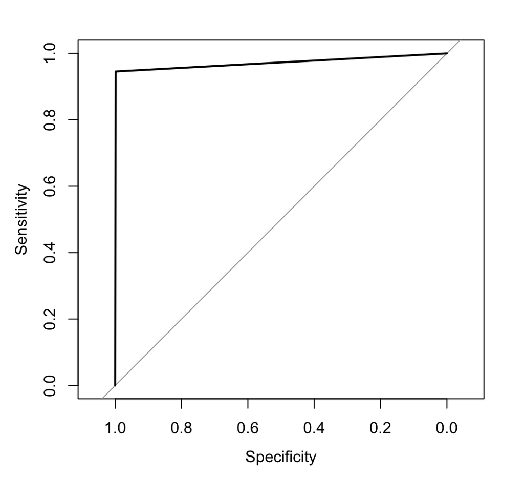

```r
plot(rocRF)
```

```r
#performance table values
auc(rocRF)
```

```
#> Area under the curve: 0.9722
```

```r
coords(rocRF,'best', ret = 'threshold')
```

```
#>   threshold
#> 1       1.5
```

```r
coords(rocRF,'best', ret = 'accuracy')
```

```
#>            accuracy
#> threshold 0.9971221
```

```r
coords(rocRF,'best', ret = 'tpr')
```

```
#>                 tpr
#> threshold 0.9455984
```

```r
coords(rocRF,'best', ret = 'fpr')
```

```
#>                   fpr
#> threshold 0.001176125
```

```r
coords(rocRF,'best', ret = 'precision')
```

```
#>           precision
#> threshold 0.9637097
```

## 3.8 SVM (Part 2)

```r
library(e1071)
#linear
svmfit <- svm(formula = BlueTarp~ Red + Green + Blue, data = train, kernel ="linear", cost = 10)
svmfit$index
```

```
#>   [1]    94    95   288   297   301   335   351   383   405   440   446   447
#>  [13]   449   491   492   493   494   500   547   548   549   553   554   555
#>  [25]   556   604   605   610   611   662   669   670   671   717   721   722
#>  [37]   770   771   772   773   774   775   776   826   827   877  1342  8244
#>  [49]  9101  9146  9152  9153  9154  9267  9268  9328  9329  9448  9987 10051
#>  [61] 10206 10217 10265 10297 10500 10557 10617 10622 10749 15898 17834 19735
#>  [73] 20001 22005 22104 22214 24306 26893 26894 26896 26897 26926 26927 26928
#>  [85] 26929 26930 26965 26980 26981 27012 27013 27014 27015 27016 27017 27018
#>  [97] 27045 27046 27062 27063 27064 27065 27066 27067 27068 27069 27103 27104
#> [109] 27105 27106 27107 27134 27135 27136 27155 27156 27157 27158 27185 27186
#> [121] 27187 27188 27189 27220 27221 27243 27277 27317 27318 28562 29106 29222
#> [133] 29228 29230 29232 29239 29252 29261 29264 29267 29277 29280 29281 29283
#> [145] 29288 29291 29317 29318 29319 29324 29325 29326 29328 29331 29332 29335
#> [157] 29336 29340 29552 29555 29557 29560 29608 29611 29617 29896 29897 29899
#> [169] 29901 29904 29906 30031 30033 30099 30279 30293 30302 30312 30313 30316
```

[output cut: 18 more lines]

```r
summary(svmfit)
```

```
#>
#> Call:
#> svm(formula = BlueTarp ~ Red + Green + Blue, data = train, kernel = "linear",
#>     cost = 10)
#>
#>
#> Parameters:
#>    SVM-Type:  C-classification
#>  SVM-Kernel:  linear
#>        cost:  10
#>
#> Number of Support Vectors:  392
#>
#>  ( 198 194 )
#>
#>
#> Number of Classes:  2
#>
#> Levels:
#>  FALSE TRUE
```

```r
svmfit <- svm(formula = BlueTarp~ Red + Green + Blue, data = train, kernel ="linear", cost = 0.1)
summary(svmfit)
```

```
#>
#> Call:
#> svm(formula = BlueTarp ~ Red + Green + Blue, data = train, kernel = "linear",
#>     cost = 0.1)
#>
#>
#> Parameters:
#>    SVM-Type:  C-classification
#>  SVM-Kernel:  linear
#>        cost:  0.1
#>
#> Number of Support Vectors:  893
#>
#>  ( 447 446 )
#>
#>
#> Number of Classes:  2
#>
#> Levels:
#>  FALSE TRUE
```

```r
tune.out <- tune(svm,BlueTarp~ Red + Green + Blue, data = train, kernel ="linear", ranges = list(cost=c(0.001,0.01,0.1,1,5,10,100,1000)))
summary(tune.out)
```

```
#>
#> Parameter tuning of 'svm':
#>
#> - sampling method: 10-fold cross validation
#>
#> - best parameters:
#>  cost
#>   100
#>
#> - best performance: 0.004806924
#>
#> - Detailed performance results:
#>    cost       error   dispersion
#> 1 1e-03 0.031972475 0.0032478662
#> 2 1e-02 0.011511391 0.0019106823
#> 3 1e-01 0.006862565 0.0013423471
#> 4 1e+00 0.005249712 0.0012039404
#> 5 5e+00 0.004965052 0.0008951080
#> 6 1e+01 0.004901791 0.0009457392
#> 7 1e+02 0.004806924 0.0008273300
#> 8 1e+03 0.004806924 0.0008273300
```

```r
#best tune
svmLinearBestTuneCost <- tune.out$best.parameters$cost
svmLinearBestTuneCost
```

```
#> [1] 100
```

```r
bestmod <- tune.out$best.model
summary(bestmod)
```

```
#>
#> Call:
#> best.tune(method = svm, train.x = BlueTarp ~ Red + Green + Blue,
#>     data = train, ranges = list(cost = c(0.001, 0.01, 0.1, 1, 5,
#>         10, 100, 1000)), kernel = "linear")
#>
#>
#> Parameters:
#>    SVM-Type:  C-classification
#>  SVM-Kernel:  linear
#>        cost:  100
#>
#> Number of Support Vectors:  365
#>
#>  ( 185 180 )
#>
#>
#> Number of Classes:  2
#>
#> Levels:
#>  FALSE TRUE
```

```r
#predict
ypred <- predict(bestmod,test)
#confusion matrix
confusionMatrix(data = ypred, reference = test$BlueTarp)
```

```
#> Confusion Matrix and Statistics
#>
#>           Reference
#> Prediction FALSE  TRUE
#>      FALSE 30578   108
#>      TRUE     31   903
#>
#>                Accuracy : 0.9956
#>                  95% CI : (0.9948, 0.9963)
#>     No Information Rate : 0.968
#>     P-Value [Acc > NIR] : < 2.2e-16
#>
#>                   Kappa : 0.9263
#>
#>  Mcnemar's Test P-Value : 1.147e-10
#>
#>             Sensitivity : 0.9990
#>             Specificity : 0.8932
#>          Pos Pred Value : 0.9965
#>          Neg Pred Value : 0.9668
#>              Prevalence : 0.9680
#>          Detection Rate : 0.9670
#>    Detection Prevalence : 0.9705
#>       Balanced Accuracy : 0.9461
#>
#>        'Positive' Class : FALSE
#>
```

```r
#radial
svmfitradial <- svm(formula = BlueTarp~ Red + Green + Blue, data = train, type= "C-classification", kernel ="radial")
summary(svmfitradial)
```

```
#>
#> Call:
#> svm(formula = BlueTarp ~ Red + Green + Blue, data = train, type = "C-classification",
#>     kernel = "radial")
#>
#>
#> Parameters:
#>    SVM-Type:  C-classification
#>  SVM-Kernel:  radial
#>        cost:  1
#>
#> Number of Support Vectors:  488
#>
#>  ( 245 243 )
#>
#>
#> Number of Classes:  2
#>
#> Levels:
#>  FALSE TRUE
```

```r
tune.radial <- tune(svm,BlueTarp~ Red + Green + Blue, data = train, kernel ="radial",ranges=list(cost=c(0.1,1,10,100,1000)))
summary(tune.radial)
```

```
#>
#> Parameter tuning of 'svm':
#>
#> - sampling method: 10-fold cross validation
#>
#> - best parameters:
#>  cost
#>  1000
#>
#> - best performance: 0.003194131
#>
#> - Detailed performance results:
#>    cost       error  dispersion
#> 1 1e-01 0.006862585 0.001430579
#> 2 1e+00 0.004490729 0.001209452
#> 3 1e+01 0.003605243 0.001056394
#> 4 1e+02 0.003352269 0.001222203
#> 5 1e+03 0.003194131 0.000959923
```

```r
svmRadialBestTuneCost <- tune.radial$best.parameters$cost

#polynomial
svmfitpoly <- svm(formula = BlueTarp~ Red + Green + Blue, data = train, type= "C-classification", kernel ="polynomial")
summary(svmfitpoly)
```

```
#>
#> Call:
#> svm(formula = BlueTarp ~ Red + Green + Blue, data = train, type = "C-classification",
#>     kernel = "polynomial")
#>
#>
#> Parameters:
#>    SVM-Type:  C-classification
#>  SVM-Kernel:  polynomial
#>        cost:  1
#>      degree:  3
#>      coef.0:  0
#>
#> Number of Support Vectors:  984
#>
#>  ( 495 489 )
#>
#>
#> Number of Classes:  2
#>
#> Levels:
#>  FALSE TRUE
```

```r
tune.poly <- tune(svm,BlueTarp~ Red + Green + Blue, data = train, kernel ="polynomial",ranges=list(cost=c(0.1,1,10,100,1000)))
summary(tune.poly)
```

```
#>
#> Parameter tuning of 'svm':
#>
#> - sampling method: 10-fold cross validation
#>
#> - best parameters:
#>  cost
#>  1000
#>
#> - best performance: 0.004237654
#>
#> - Detailed performance results:
#>    cost       error   dispersion
#> 1 1e-01 0.015938679 0.0023240804
#> 2 1e+00 0.010594150 0.0015214843
#> 3 1e+01 0.006609501 0.0009479053
#> 4 1e+02 0.005091524 0.0013535720
#> 5 1e+03 0.004237654 0.0013182008
```

```r
svmPolyBestTuneCost <- tune.poly$best.parameters$cost

#sigmoid
svmsigmoid <- svm(formula = BlueTarp~ Red + Green + Blue, data = train, type= "C-classification", kernel ="sigmoid")
summary(svmsigmoid)
```

```
#>
#> Call:
#> svm(formula = BlueTarp ~ Red + Green + Blue, data = train, type = "C-classification",
#>     kernel = "sigmoid")
#>
#>
#> Parameters:
#>    SVM-Type:  C-classification
#>  SVM-Kernel:  sigmoid
#>        cost:  1
#>      coef.0:  0
#>
#> Number of Support Vectors:  1169
#>
#>  ( 585 584 )
#>
#>
#> Number of Classes:  2
#>
#> Levels:
#>  FALSE TRUE
```

```r
tune.sigmoid <- tune(svm,BlueTarp~ Red + Green + Blue, data = train, kernel ="sigmoid",ranges=list(cost=c(0.1,1,10,100,1000)))
summary(tune.sigmoid)
```

```
#>
#> Parameter tuning of 'svm':
#>
#> - sampling method: 10-fold cross validation
#>
#> - best parameters:
#>  cost
#>   0.1
#>
#> - best performance: 0.01951235
#>
#> - Detailed performance results:
#>    cost      error  dispersion
#> 1 1e-01 0.01951235 0.002481455
#> 2 1e+00 0.03273134 0.003715124
#> 3 1e+01 0.03592544 0.004000344
#> 4 1e+02 0.03636820 0.003872893
#> 5 1e+03 0.03636820 0.003872893
```

```r
svmSigmoidBestTuneCost <- tune.sigmoid$best.parameters$cost

#table comparing values of best tune performance
TunePerformanceList <- list(tune.out$best.performance,tune.radial$best.performance,tune.poly$best.performance,tune.sigmoid$best.performance)

TunePerformanceDF <- as.data.frame(TunePerformanceList)
colnames(TunePerformanceDF) <- c('Linear','Radial Basis','Polynomial','Sigmoid')
TunePerformanceDF <- data.frame(TunePerformanceDF, row.names = "Best Performance (Error Rate)")
TunePerformanceDF
```

```
#>                                    Linear Radial.Basis  Polynomial    Sigmoid
#> Best Performance (Error Rate) 0.004806924  0.003194131 0.004237654 0.01951235
```

```r
#radial has a lowest best performance (error rate). go with radial model

bestmod <- tune.radial$best.model
summary(bestmod)
```

```
#>
#> Call:
#> best.tune(method = svm, train.x = BlueTarp ~ Red + Green + Blue,
#>     data = train, ranges = list(cost = c(0.1, 1, 10, 100, 1000)),
#>     kernel = "radial")
#>
#>
#> Parameters:
#>    SVM-Type:  C-classification
#>  SVM-Kernel:  radial
#>        cost:  1000
#>
#> Number of Support Vectors:  237
#>
#>  ( 123 114 )
#>
#>
#> Number of Classes:  2
#>
#> Levels:
#>  FALSE TRUE
```

```r
#predict
ypred <- predict(bestmod,test,decision.values = TRUE)
fitted <- attributes(ypred)$decision.values
#confusion matrix
confusionMatrix(data = ypred, reference = test$BlueTarp)
```

```
#> Confusion Matrix and Statistics
#>
#>           Reference
#> Prediction FALSE  TRUE
#>      FALSE 30563    49
#>      TRUE     46   962
#>
#>                Accuracy : 0.997
#>                  95% CI : (0.9963, 0.9976)
#>     No Information Rate : 0.968
#>     P-Value [Acc > NIR] : <2e-16
#>
#>                   Kappa : 0.9514
#>
#>  Mcnemar's Test P-Value : 0.8374
#>
#>             Sensitivity : 0.9985
#>             Specificity : 0.9515
#>          Pos Pred Value : 0.9984
#>          Neg Pred Value : 0.9544
#>              Prevalence : 0.9680
#>          Detection Rate : 0.9666
#>    Detection Prevalence : 0.9681
#>       Balanced Accuracy : 0.9750
#>
#>        'Positive' Class : FALSE
#>
```

```r
#roc
my_roc_svm <- roc(test$BlueTarp,fitted)
```

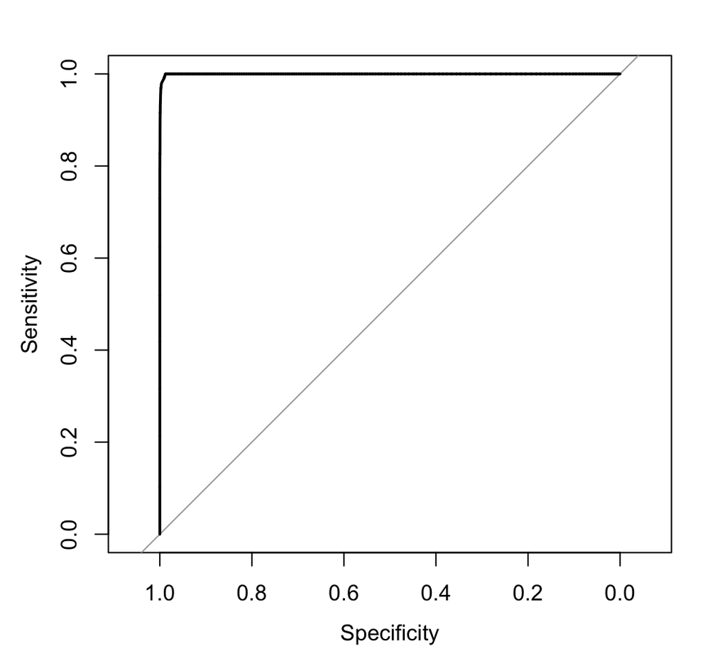

```r
plot(my_roc_svm)
```

```r
#performance table values
auc(my_roc_svm)
```

```
#> Area under the curve: 0.9997
```

```r
coords(my_roc_svm,'best', ret = 'threshold')
```

```
#>   threshold
#> 1  1.846778
```

```r
coords(my_roc_svm,'best', ret = 'accuracy')
```

```
#>            accuracy
#> threshold 0.9885832
```

```r
coords(my_roc_svm,'best', ret = 'tpr')
```

```
#>           tpr
#> threshold   1
```

```r
coords(my_roc_svm,'best', ret = 'fpr')
```

```
#>                  fpr
#> threshold 0.01179392
```

```r
coords(my_roc_svm,'best', ret = 'precision')
```

```
#>           precision
#> threshold 0.7368805
```

**NOTE: PART II same as above plus add Random Forest and SVM to Model Training.**

## 3.9 Threshold Selection

We were able to find the best threshold for each model through the pROC library using the coords function. The threshold that we ended up using was selected using this process. It proved very effective since all of our models had a high accuracy.

# 4 Results (Cross-Validation)

```r
#glm
list.glm <- list('n/a', as.numeric(my_roc_glm$auc),as.numeric(coords(my_roc_glm,'best',ret = 'threshold')),as.numeric(coords(my_roc_glm,'best', ret = 'accuracy')),as.numeric(coords(my_roc_glm,'best', ret = 'tpr')),as.numeric(coords(my_roc_glm,'best', ret = 'fpr')),as.numeric(coords(my_roc_glm,'best', ret = 'precision')))
df_glm <- as.data.frame(list.glm)
df_glm <- data.frame(df_glm, row.names = 'Log Reg')
colnames(df_glm) <- c('Tuning','AUROC','Threshold','Accuracy','TPR','FPR',  'Precision')
df_glm
```

```
#>         Tuning     AUROC Threshold  Accuracy       TPR        FPR Precision
#> Log Reg    n/a 0.9982741 0.0571714 0.9886781 0.9772502 0.01094449 0.7467876
```

```r
#lda
list.lda <- list(list('n/a', as.numeric(my_roc_lda$auc),as.numeric(coords(my_roc_lda,'best',ret = 'threshold')),as.numeric(coords(my_roc_lda,'best', ret = 'accuracy')),as.numeric(coords(my_roc_lda,'best', ret = 'tpr')),as.numeric(coords(my_roc_lda,'best', ret = 'fpr')),as.numeric(coords(my_roc_lda,'best', ret = 'precision'))))

df_lda <- as.data.frame(list.lda)
df_lda <- data.frame(df_lda,row.names = 'LDA')
colnames(df_lda) <- c('Tuning','AUROC','Threshold','Accuracy','TPR','FPR',  'Precision')
df_lda
```

```
#>     Tuning     AUROC Threshold  Accuracy       TPR        FPR Precision
#> LDA    n/a 0.9898067   1.66575 0.9633776 0.9159248 0.03505505 0.4632316
```

```r
#qda

list.qda <- list(list('n/a', as.numeric(my_roc_qda$auc),as.numeric(coords(my_roc_qda,'best',ret = 'threshold')),as.numeric(coords(my_roc_qda,'best', ret = 'accuracy')),as.numeric(coords(my_roc_qda,'best', ret = 'tpr')),as.numeric(coords(my_roc_qda,'best', ret = 'fpr')),as.numeric(coords(my_roc_qda,'best', ret = 'precision'))))

df_qda <- as.data.frame(list.qda)
df_qda <- data.frame(df_qda,row.names = 'QDA')
colnames(df_qda) <- c('Tuning','AUROC','Threshold','Accuracy','TPR','FPR',  'Precision')
df_qda
```

```
#>     Tuning     AUROC Threshold  Accuracy       TPR          FPR Precision
#> QDA    n/a 0.9246799       1.5 0.9949083 0.8496538 0.0002940312 0.9896313
```

```r
#knn
list.knn <- list(list(as.numeric(knnBestTune), as.numeric(my_roc_knn$auc),as.numeric(coords(my_roc_knn,'best',ret = 'threshold')),as.numeric(coords(my_roc_knn,'best', ret = 'accuracy')),as.numeric(coords(my_roc_knn,'best', ret = 'tpr')),as.numeric(coords(my_roc_knn,'best', ret = 'fpr')),as.numeric(coords(my_roc_knn,'best', ret = 'precision'))))

df_knn <- as.data.frame(list.knn)
df_knn <- data.frame(df_knn,row.names = 'KNN')
colnames(df_knn) <- c('Tuning','AUROC','Threshold','Accuracy','TPR','FPR',  'Precision')
df_knn
```

```
#>     Tuning     AUROC Threshold  Accuracy       TPR         FPR Precision
#> KNN      9 0.9767974       1.5 0.9967426 0.9554896 0.001894868 0.9433594
```

```r
#elastic

list.elastic <- list(list(model.elastic$bestTune$lambda, as.numeric(my_roc_elastic$auc),as.numeric(coords(my_roc_elastic,'best',ret = 'threshold')),as.numeric(coords(my_roc_elastic,'best', ret = 'accuracy')),as.numeric(coords(my_roc_elastic,'best', ret = 'tpr')),as.numeric(coords(my_roc_elastic,'best', ret = 'fpr')),as.numeric(coords(my_roc_elastic,'best', ret = 'precision'))))

df_elastic <- as.data.frame(list.elastic)
df_elastic <- data.frame(df_elastic,row.names = 'Penalized Log Reg')
colnames(df_elastic) <- c('Tuning','AUROC','Threshold','Accuracy','TPR','FPR',  'Precision')
df_elastic
```

```
#>                         Tuning     AUROC Threshold Accuracy       TPR
#> Penalized Log Reg 1.901767e-05 0.9402118       1.5 0.995351 0.8813056
#>                            FPR Precision
#> Penalized Log Reg 0.0008820935 0.9705882
```

```r
#Part 2
#random forest
list.rf <- list(list(rfmodBestTune, as.numeric(rocRF$auc),as.numeric(coords(rocRF,'best',ret = 'threshold')),as.numeric(coords(rocRF,'best', ret = 'accuracy')),as.numeric(coords(rocRF,'best', ret = 'tpr')),as.numeric(coords(rocRF,'best', ret = 'fpr')),as.numeric(coords(rocRF,'best', ret = 'precision'))))

df_rf <- as.data.frame(list.rf)
df_rf <- data.frame(df_rf,row.names = 'Random Forest')
colnames(df_rf) <- c('Tuning','AUROC','Threshold','Accuracy','TPR','FPR',   'Precision')
df_rf
```

```
#>               Tuning     AUROC Threshold  Accuracy       TPR         FPR
#> Random Forest      2 0.9722111       1.5 0.9971221 0.9455984 0.001176125
#>               Precision
#> Random Forest 0.9637097
```

```r
#svm
list.svmCost <- list(svmRadialBestTuneCost, as.numeric(my_roc_svm$auc),as.numeric(coords(my_roc_svm,'best',ret = 'threshold')),as.numeric(coords(my_roc_svm,'best', ret = 'accuracy')),as.numeric(coords(my_roc_svm,'best', ret = 'tpr')),as.numeric(coords(my_roc_svm,'best', ret = 'fpr')),as.numeric(coords(my_roc_svm,'best', ret = 'precision')))

df_svmCost <- as.data.frame(list.svmCost)
df_svmCost <- data.frame(df_svmCost,row.names = 'Support Vector Machine')
colnames(df_svmCost) <- c('Tuning','AUROC','Threshold','Accuracy','TPR','FPR',  'Precision')
df_svmCost
```

```
#>                        Tuning     AUROC Threshold  Accuracy TPR        FPR
#> Support Vector Machine   1000 0.9996885  1.846778 0.9885832   1 0.01179392
#>                        Precision
#> Support Vector Machine 0.7368805
```

```r
#Perf Table

PerfTable <- rbind(df_glm,df_lda,df_qda,df_knn,df_elastic,df_rf,df_svmCost)
colnames(PerfTable) <- c('Tuning','AUROC','Threshold','Accuracy','TPR','FPR',   'Precision')

PerfTable
```

```
#>                                      Tuning     AUROC Threshold  Accuracy
#> Log Reg                                 n/a 0.9982741 0.0571714 0.9886781
#> LDA                                     n/a 0.9898067 1.6657501 0.9633776
#> QDA                                     n/a 0.9246799 1.5000000 0.9949083
#> KNN                                       9 0.9767974 1.5000000 0.9967426
#> Penalized Log Reg      1.90176708411387e-05 0.9402118 1.5000000 0.9953510
#> Random Forest                             2 0.9722111 1.5000000 0.9971221
#> Support Vector Machine                 1000 0.9996885 1.8467776 0.9885832
#>                              TPR          FPR Precision
#> Log Reg                0.9772502 0.0109444934 0.7467876
#> LDA                    0.9159248 0.0350550492 0.4632316
#> QDA                    0.8496538 0.0002940312 0.9896313
#> KNN                    0.9554896 0.0018948675 0.9433594
#> Penalized Log Reg      0.8813056 0.0008820935 0.9705882
#> Random Forest          0.9455984 0.0011761247 0.9637097
#> Support Vector Machine 1.0000000 0.0117939168 0.7368805
```

# 5 Conclusions

### 5.0.1 Conclusion #1

After engineering and testing all the models, I have concluded that the KNN approach proved to have the best results. We were able to successfully predict Blue Tarps at a 99.7% accuracy.We calculated this accuracy by creating a confusion matrix which shows how our model predicted on the test data set and compared it to the actual values.

### 5.0.2 Conclusion #2

After evaluating all the models, I concluded that KNN provided the best results but we also found other models that performed well. QDA and Elastic net had accuracy slightly lower than KNN but were more precise than KNN. I chose KNN over QDA and Elastic net because we were prioritizing accuracy in this simulation.

### 5.0.3 Conclusion #3

I think the approach that I took would help save lives by being able to accurately predict where the displaced individuals are. All the models tested very well and tested very accurately. Being able to predict efficiently and accurately in this kind of situation is very important and the models I tested and ended up choosing to predict where the Blue Tents were showed these characteristics.

### 5.0.4 Conclusion #4

One thing that I could do different that may improve results is to use a multinomial approach instead of binomial. I set my factor to a Boolean. It was either Blue Tarp or not Blue Tarp, even though the original data set had more than just Blue Tarp as a category. I think that this may help improve the overall prediction since it would be more representative of the real world. I think that the multinomial approach would work better than binomial.

# 6 Hold-out Data / EDA

Load data, explore data, etc.

```r
proj_dir = "~/Desktop/Grad School/2021 Spring/SYS 6018/Project" # set the project directory where data is stored (relative path)
#-- Get List of files in the zipped directory
unzip(file.path(proj_dir, "Hold+Out+Data.zip"), list=TRUE)
```

```
#>                                    Name   Length                Date
#> 1   orthovnir057_ROI_NON_Blue_Tarps.txt 83238900 2019-11-05 12:15:00
#> 2       orthovnir067_ROI_Blue_Tarps.txt   364839 2019-11-05 11:47:00
#> 3  orthovnir067_ROI_Blue_Tarps_data.txt    60040 2019-11-05 20:59:00
#> 4   orthovnir067_ROI_NOT_Blue_Tarps.txt 25637994 2019-11-05 11:48:00
#> 5       orthovnir069_ROI_Blue_Tarps.txt   560163 2019-11-05 11:55:00
#> 6   orthovnir069_ROI_NOT_Blue_Tarps.txt 24823110 2019-11-05 11:57:00
#> 7  orthovnir071_makeshift_villiage1.jpg    89774 2019-11-05 12:02:00
#> 8  orthovnir071_makeshift_villiage2.jpg    66859 2019-11-05 12:04:00
#> 9  orthovnir078_makeshift_villiage1.jpg   113974 2019-11-05 12:10:00
#> 10      orthovnir078_ROI_Blue_Tarps.txt   263158 2019-11-05 12:12:00
#> 11  orthovnir078_ROI_NON_Blue_Tarps.txt 34414902 2019-11-05 12:14:00
```

```r
#-- Unzip all files into `project` directory
unzip(file.path(proj_dir, "Hold+Out+Data.zip"), # path to zipped file
exdir = proj_dir) # path to unzipped location

read_lines(file.path(proj_dir, "orthovnir057_ROI_NON_Blue_Tarps.txt"),
n_max = 15)
```

```
#>  [1] "; ENVI Output of ROIs (5.5.1) [Tue Nov 05 11:28:14 2019]"
#>  [2] "; Number of ROIs: 1"
#>  [3] "; File Dimension: 4001 x 5447"
#>  [4] ";"
#>  [5] "; ROI name: Region #1"
#>  [6] "; ROI rgb value: {255, 0, 0}"
#>  [7] "; ROI npts: 3991823"
#>  [8] ";       ID     X     Y      Map X       Map Y        Lat         Lon   B1   B2   B3"
#>  [9] "         1  1745  1128  769849.55  2049926.90  18.522675  -72.443989  104   89   63"
#> [10] "         2  1745  1129  769849.55  2049926.82  18.522674  -72.443989  101   80   60"
#> [11] "         3  1746  1129  769849.64  2049926.82  18.522674  -72.443989  103   87   69"
#> [12] "         4  1747  1129  769849.72  2049926.82  18.522674  -72.443988  107   93   72"
#> [13] "         5  1748  1129  769849.80  2049926.82  18.522674  -72.443987  109   99   68"
#> [14] "         6  1744  1129  769849.47  2049926.82  18.522674  -72.443990  103   73   53"
#> [15] "         7  1743  1130  769849.39  2049926.74  18.522674  -72.443991  100   79   56"
```

```r
#orthovnir057_ROI_NON_Blue_Tarps
ortho057_noblue = read_table(file.path(proj_dir, "orthovnir057_ROI_NON_Blue_Tarps.txt"),
skip=7, col_types = cols(`;`="-", ID = "c")) %>%
rename(Red=B1, Green=B2, Blue=B3)
ortho057_noblue$BlueTarp = 'FALSE'
ortho057_noblue <- ortho057_noblue[, - c(1:7)]

#orthovnir067_ROI_Blue_Tarps_data
read_lines(file.path(proj_dir, "orthovnir067_ROI_Blue_Tarps_data.txt"),
n_max = 15)
```

```
#>  [1] ";\tB1\tB2\tB3"  "\t77\t94\t99"   "\t79\t98\t103"  "\t77\t99\t102"
#>  [5] "\t76\t94\t99"   "\t80\t95\t103"  "\t80\t96\t107"  "\t80\t96\t106"
#>  [9] "\t79\t95\t105"  "\t78\t96\t104"  "\t77\t95\t103"  "\t76\t91\t100"
#> [13] "\t74\t89\t97"   "\t82\t100\t116" "\t81\t99\t114"
```

```r
orthovnir067_blue_tarps_data = read.delim(file.path(proj_dir,"orthovnir067_ROI_Blue_Tarps_data.txt"),
header = TRUE) %>%
  rename(Red=B1, Green=B2, Blue=B3)
orthovnir067_blue_tarps_data$BlueTarp = 'TRUE'
orthovnir067_blue_tarps_data <- orthovnir067_blue_tarps_data[,-c(1)]

#orthovnir067_ROI_Blue_Tarps
orthovnir067_BlueTarps = read_table(file.path(proj_dir, "orthovnir067_ROI_Blue_Tarps.txt"),
skip=7, col_types = cols(`;`="-", ID = "c")) %>%
rename(Red=B1, Green=B2, Blue=B3)
orthovnir067_BlueTarps$BlueTarp <- 'TRUE'
orthovnir067_BlueTarps<- orthovnir067_BlueTarps[, - c(1:7)]

#orthovnir067_ROI_NOT_Blue_Tarps
orthovnir067_NOT_Blue_Tarps = read_table(file.path(proj_dir, "orthovnir067_ROI_NOT_Blue_Tarps.txt"),
skip=7, col_types = cols(`;`="-", ID = "c")) %>%
rename(Red=B1, Green=B2, Blue=B3)
orthovnir067_NOT_Blue_Tarps$BlueTarp <- 'FALSE'
orthovnir067_NOT_Blue_Tarps <- orthovnir067_NOT_Blue_Tarps[,-c(1:7)]


#orthovnir069_ROI_Blue_Tarps
orthovnir069_Blue_Tarps = read_table(file.path(proj_dir, "orthovnir069_ROI_Blue_Tarps.txt"),
skip=7, col_types = cols(`;`="-", ID = "c")) %>%
rename(Red=B1, Green=B2, Blue=B3)
orthovnir069_Blue_Tarps$BlueTarp <- 'TRUE'
orthovnir069_Blue_Tarps <- orthovnir069_Blue_Tarps[,-c(1:7)]

#orthovnir069_ROI_NOT_Blue_Tarps
orthovnir069_Not_Blue_Tarps = read_table(file.path(proj_dir, "orthovnir069_ROI_NOT_Blue_Tarps.txt"),
skip=7, col_types = cols(`;`="-", ID = "c")) %>%
rename(Red=B1, Green=B2, Blue=B3)
orthovnir069_Not_Blue_Tarps$BlueTarp <- 'FALSE'
orthovnir069_Not_Blue_Tarps<- orthovnir069_Not_Blue_Tarps[,-c(1:7)]

#orthovnir078_ROI_Blue_Tarps
orthovnir078_Blue_Tarps = read_table(file.path(proj_dir, "orthovnir078_ROI_Blue_Tarps.txt"),
skip=7, col_types = cols(`;`="-", ID = "c")) %>%
rename(Red=B1, Green=B2, Blue=B3)
orthovnir078_Blue_Tarps$BlueTarp <- 'TRUE'
orthovnir078_Blue_Tarps<- orthovnir078_Blue_Tarps[,-c(1:7)]

#orthovnir078_ROI_NON_Blue_Tarps
orthovnir078_NON_Blue_Tarps = read_table(file.path(proj_dir, "orthovnir078_ROI_NON_Blue_Tarps.txt"),
skip=7, col_types = cols(`;`="-", ID = "c")) %>%
rename(Red=B1, Green=B2, Blue=B3)
orthovnir078_NON_Blue_Tarps$BlueTarp <- 'FALSE'
orthovnir078_NON_Blue_Tarps<- orthovnir078_NON_Blue_Tarps[,-c(1:7)]

HoldOutData <- rbind(ortho057_noblue,orthovnir067_blue_tarps_data,orthovnir067_BlueTarps,orthovnir067_NOT_Blue_Tarps,orthovnir069_Blue_Tarps,orthovnir069_Not_Blue_Tarps,orthovnir078_Blue_Tarps,orthovnir078_NON_Blue_Tarps)


HoldOutData$BlueTarp <- factor(HoldOutData$BlueTarp)
HoldOutData$Red <- as.integer(HoldOutData$Red)
HoldOutData$Green <- as.integer(HoldOutData$Green)
HoldOutData$Blue <- as.integer(HoldOutData$Blue)
```

# 7 Performance with Hold Out Data

## 7.1 Logistic Regression

```r
glm.fitsHoldOut <- glm(BlueTarp ~ Red + Green + Blue, family = 'binomial', data = data)
glm.predictHoldOut <- predict(glm.fitsHoldOut, newdata = HoldOutData, type="response")
#confusionMatrix NEED TO FIX THIS
confusionMatrix(data = factor(glm.predictHoldOut>=0.5), reference = HoldOutData$BlueTarp)
```

```
#> Confusion Matrix and Statistics
#>
#>           Reference
#> Prediction   FALSE    TRUE
#>      FALSE 1969385     170
#>      TRUE    20312   18756
#>
#>                Accuracy : 0.9898
#>                  95% CI : (0.9897, 0.9899)
#>     No Information Rate : 0.9906
#>     P-Value [Acc > NIR] : 1
#>
#>                   Kappa : 0.6423
#>
#>  Mcnemar's Test P-Value : <2e-16
#>
#>             Sensitivity : 0.9898
#>             Specificity : 0.9910
#>          Pos Pred Value : 0.9999
#>          Neg Pred Value : 0.4801
#>              Prevalence : 0.9906
#>          Detection Rate : 0.9805
#>    Detection Prevalence : 0.9805
#>       Balanced Accuracy : 0.9904
#>
#>        'Positive' Class : FALSE
#>
```

```r
#proc
my_roc_glmHoldOut <- roc(HoldOutData$BlueTarp,glm.predictHoldOut)
```

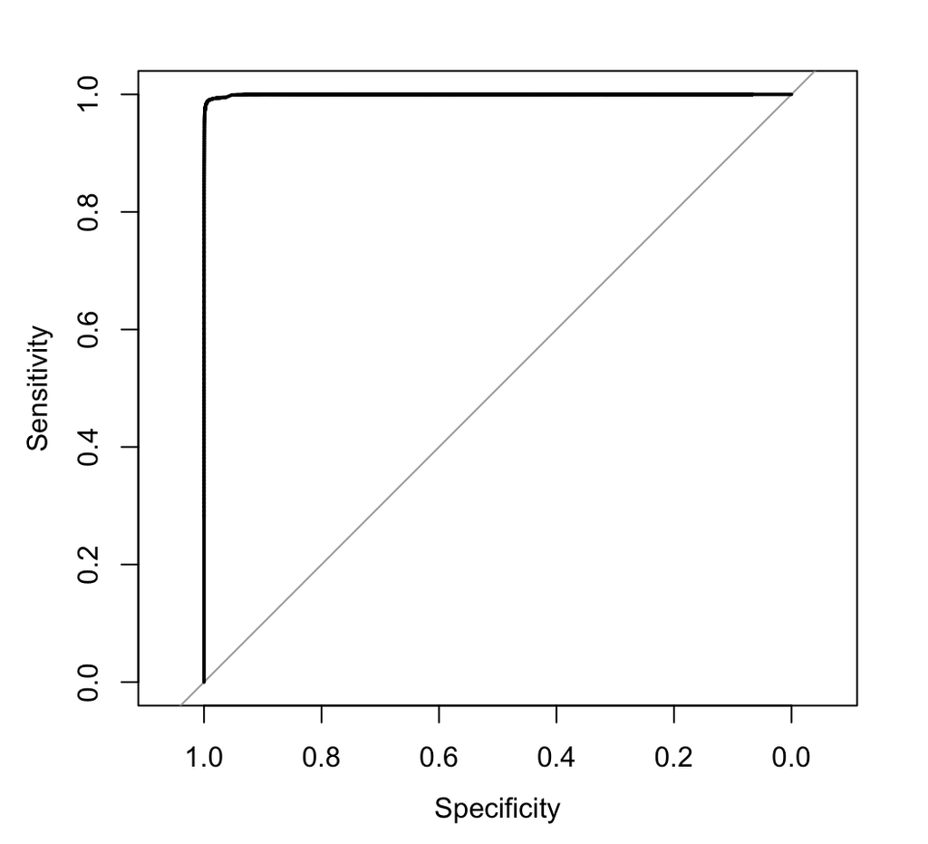

```r
plot(my_roc_glmHoldOut)
```

```r
#performance values
auc.glmHoldOut <- auc(my_roc_glmHoldOut)
coords(my_roc_glmHoldOut,'best',ret = 'threshold')
```

```
#>   threshold
#> 1 0.6513031
```

```r
coords(my_roc_glmHoldOut,'best', ret = 'accuracy')
```

```
#>            accuracy
#> threshold 0.9939829
```

```r
coords(my_roc_glmHoldOut,'best', ret = 'tpr')
```

```
#>                 tpr
#> threshold 0.9884815
```

```r
coords(my_roc_glmHoldOut,'best', ret = 'fpr')
```

```
#>                   fpr
#> threshold 0.005964727
```

```r
coords(my_roc_glmHoldOut,'best', ret = 'precision')
```

```
#>           precision
#> threshold 0.6118524
```

## 7.2 LDA

```r
lda.fitsHoldOut <- lda(BlueTarp ~ Red + Green + Blue, family = 'binomial', data=data)


lda.predictHoldOut <- predict(lda.fitsHoldOut, newdata = HoldOutData, family = 'binomial')

#confusionMatrix
confusionMatrix(data = lda.predictHoldOut$class, reference = HoldOutData$BlueTarp)
```

```
#> Confusion Matrix and Statistics
#>
#>           Reference
#> Prediction   FALSE    TRUE
#>      FALSE 1955993    2546
#>      TRUE    33704   16380
#>
#>                Accuracy : 0.982
#>                  95% CI : (0.9818, 0.9821)
#>     No Information Rate : 0.9906
#>     P-Value [Acc > NIR] : 1
#>
#>                   Kappa : 0.4674
#>
#>  Mcnemar's Test P-Value : <2e-16
#>
#>             Sensitivity : 0.9831
#>             Specificity : 0.8655
#>          Pos Pred Value : 0.9987
#>          Neg Pred Value : 0.3271
#>              Prevalence : 0.9906
#>          Detection Rate : 0.9738
#>    Detection Prevalence : 0.9751
#>       Balanced Accuracy : 0.9243
#>
#>        'Positive' Class : FALSE
#>
```

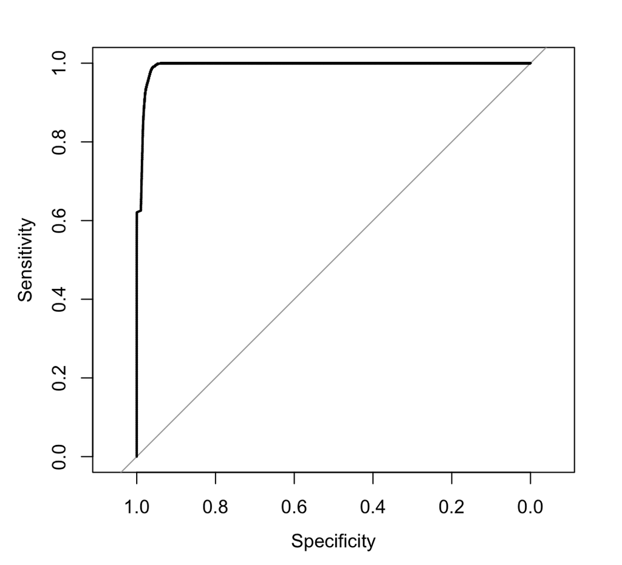

```r
#roc curve
#proc
my_roc_ldaHoldOut <- roc(HoldOutData$BlueTarp,lda.predictHoldOut$x)
plot(my_roc_ldaHoldOut)
```

```r
#performance table values
auc(my_roc_ldaHoldOut)
```

```
#> Area under the curve: 0.9932
```

```r
coords(my_roc_ldaHoldOut,'best', ret = 'threshold')
```

```
#>   threshold
#> 1  1.689528
```

```r
coords(my_roc_ldaHoldOut,'best', ret = 'accuracy')
```

```
#>            accuracy
#> threshold 0.9603783
```

```r
coords(my_roc_ldaHoldOut,'best', ret = 'tpr')
```

```
#>                 tpr
#> threshold 0.9883758
```

```r
coords(my_roc_ldaHoldOut,'best', ret = 'fpr')
```

```
#>                  fpr
#> threshold 0.03988798
```

```r
coords(my_roc_ldaHoldOut,'best', ret = 'precision')
```

```
#>           precision
#> threshold 0.1907394
```

## 7.3 QDA

```r
qda.fitsHoldOut <- qda(BlueTarp ~ Red + Green +Blue, family = 'binomial', data=data)

#predict
qda.predictHoldOut <- predict(qda.fitsHoldOut, newdata = HoldOutData, family = 'binomial')

#confusion matrix
confusionMatrix(reference = HoldOutData$BlueTarp, data = qda.predictHoldOut$class)
```

```
#> Confusion Matrix and Statistics
#>
#>           Reference
#> Prediction   FALSE    TRUE
#>      FALSE 1982817    8489
#>      TRUE     6880   10437
#>
#>                Accuracy : 0.9923
#>                  95% CI : (0.9922, 0.9925)
#>     No Information Rate : 0.9906
#>     P-Value [Acc > NIR] : < 2.2e-16
#>
#>                   Kappa : 0.5721
#>
#>  Mcnemar's Test P-Value : < 2.2e-16
#>
#>             Sensitivity : 0.9965
#>             Specificity : 0.5515
#>          Pos Pred Value : 0.9957
#>          Neg Pred Value : 0.6027
#>              Prevalence : 0.9906
#>          Detection Rate : 0.9872
#>    Detection Prevalence : 0.9914
#>       Balanced Accuracy : 0.7740
#>
#>        'Positive' Class : FALSE
#>
```

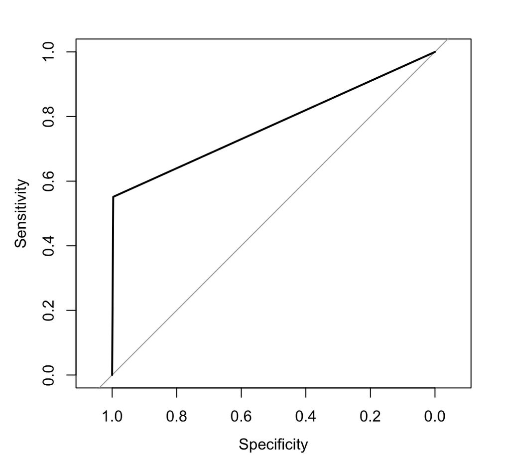

```r
#roc curve
#proc
my_roc_qdaHoldOut <- roc(HoldOutData$BlueTarp,as.numeric(qda.predictHoldOut$class))
plot(my_roc_qdaHoldOut)
```

```r
#performance table values
auc(my_roc_qdaHoldOut)
```

```
#> Area under the curve: 0.774
```

```r
coords(my_roc_qdaHoldOut,'best',ret = 'threshold')
```

```
#>   threshold
#> 1       1.5
```

```r
coords(my_roc_qdaHoldOut,'best', ret = 'accuracy')
```

```
#>            accuracy
#> threshold 0.9923485
```

```r
coords(my_roc_qdaHoldOut,'best', ret = 'tpr')
```

```
#>                 tpr
#> threshold 0.5514636
```

```r
coords(my_roc_qdaHoldOut,'best', ret = 'fpr')
```

```
#>                   fpr
#> threshold 0.003457813
```

```r
coords(my_roc_qdaHoldOut,'best', ret = 'precision')
```

```
#>           precision
#> threshold 0.6027025
```

## 7.4 KNN

```r
knn.fitsHoldOut <- knn3(BlueTarp ~ Red + Green +Blue,data = data, k = knnBestTune)


#predict
knn.predictHoldOut <- predict(knn.fitsHoldOut, newdata = HoldOutData, type = 'class')


#confusion matrix
confusionMatrix(table(predicted = knn.predictHoldOut,
                      reference = HoldOutData$BlueTarp))
```

```
#> Confusion Matrix and Statistics
#>
#>          reference
#> predicted   FALSE    TRUE
#>     FALSE 1976613    2190
#>     TRUE    13084   16736
#>
#>                Accuracy : 0.9924
#>                  95% CI : (0.9923, 0.9925)
#>     No Information Rate : 0.9906
#>     P-Value [Acc > NIR] : < 2.2e-16
#>
#>                   Kappa : 0.683
#>
#>  Mcnemar's Test P-Value : < 2.2e-16
#>
#>             Sensitivity : 0.9934
#>             Specificity : 0.8843
#>          Pos Pred Value : 0.9989
#>          Neg Pred Value : 0.5612
#>              Prevalence : 0.9906
#>          Detection Rate : 0.9841
#>    Detection Prevalence : 0.9852
#>       Balanced Accuracy : 0.9389
#>
#>        'Positive' Class : FALSE
#>
```

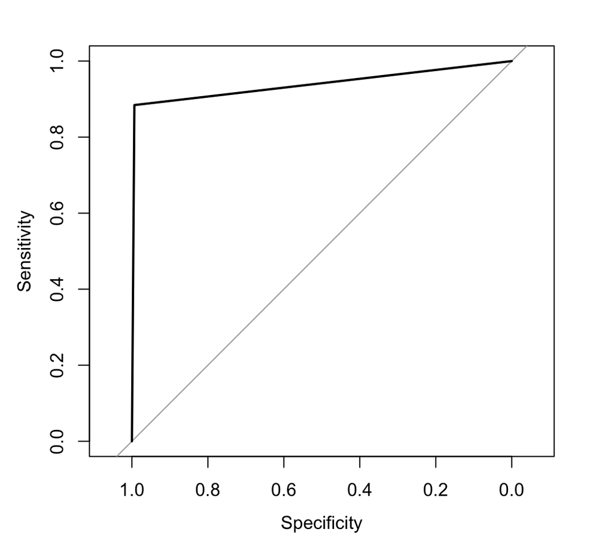

```r
#roc curve
#proc
my_roc_knnHoldOut <- roc(HoldOutData$BlueTarp,as.numeric(knn.predictHoldOut))
plot(my_roc_knnHoldOut)
```

```r
#performance table values
auc(my_roc_knnHoldOut)
```

```
#> Area under the curve: 0.9389
```

```r
coords(my_roc_knnHoldOut,'best',ret = 'threshold')
```

```
#>   threshold
#> 1       1.5
```

```r
coords(my_roc_knnHoldOut,'best', ret = 'accuracy')
```

```
#>            accuracy
#> threshold 0.9923958
```

```r
coords(my_roc_knnHoldOut,'best', ret = 'tpr')
```

```
#>                 tpr
#> threshold 0.8842862
```

```r
coords(my_roc_knnHoldOut,'best', ret = 'fpr')
```

```
#>                   fpr
#> threshold 0.006575876
```

```r
coords(my_roc_knnHoldOut,'best', ret = 'precision')
```

```
#>           precision
#> threshold 0.5612341
```

## 7.5 Penalized Logistic Regression (ElasticNet)

```r
#Elastic net
#model.elastic
predictions.elasticHoldOut <- predict(model.elastic,newdata = HoldOutData)


#confusion matrix
confusionMatrix(table(predicted = predictions.elasticHoldOut,
                      reference = HoldOutData$BlueTarp))
```

```
#> Confusion Matrix and Statistics
#>
#>          reference
#> predicted   FALSE    TRUE
#>     FALSE 1976627     191
#>     TRUE    13070   18735
#>
#>                Accuracy : 0.9934
#>                  95% CI : (0.9933, 0.9935)
#>     No Information Rate : 0.9906
#>     P-Value [Acc > NIR] : < 2.2e-16
#>
#>                   Kappa : 0.7355
#>
#>  Mcnemar's Test P-Value : < 2.2e-16
#>
#>             Sensitivity : 0.9934
#>             Specificity : 0.9899
#>          Pos Pred Value : 0.9999
#>          Neg Pred Value : 0.5891
#>              Prevalence : 0.9906
#>          Detection Rate : 0.9841
#>    Detection Prevalence : 0.9842
#>       Balanced Accuracy : 0.9917
#>
#>        'Positive' Class : FALSE
#>
```

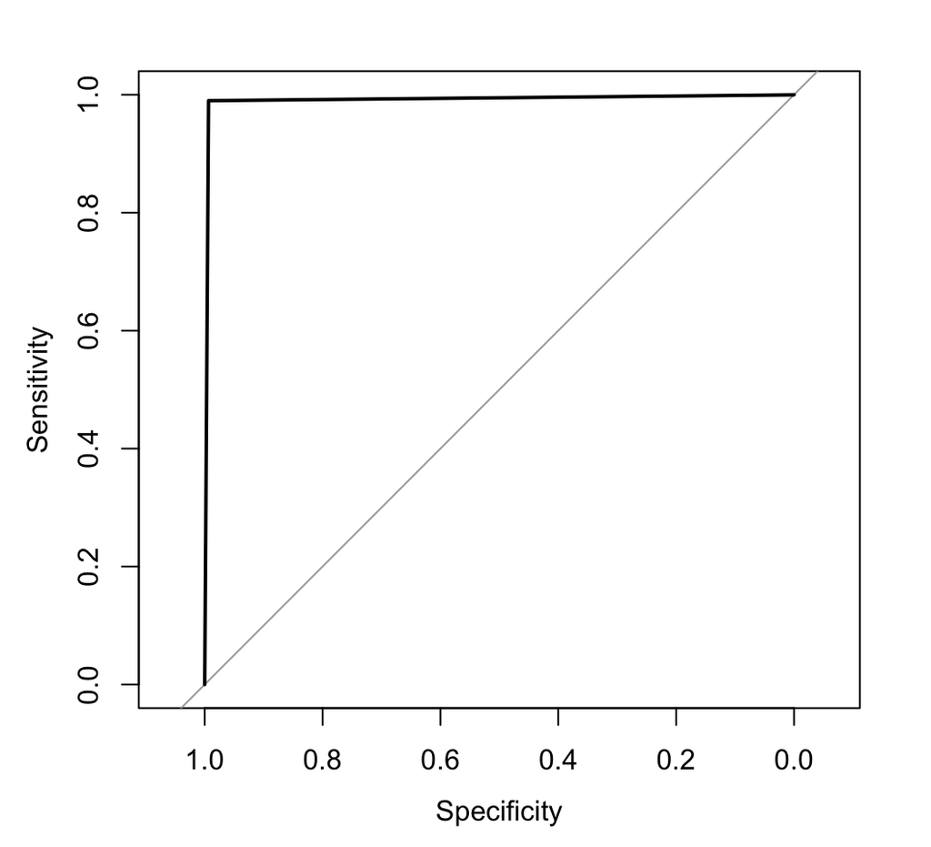

```r
#roc curve
#proc
my_roc_elasticHoldOut <- roc(HoldOutData$BlueTarp,as.numeric(predictions.elasticHoldOut))
plot(my_roc_elasticHoldOut)
```

```r
#performance table values
auc(my_roc_elasticHoldOut)
```

```
#> Area under the curve: 0.9917
```

```r
coords(my_roc_elasticHoldOut,'best',ret = 'threshold')
```

```
#>   threshold
#> 1       1.5
```

```r
coords(my_roc_elasticHoldOut,'best', ret = 'accuracy')
```

```
#>           accuracy
#> threshold 0.993398
```

```r
coords(my_roc_elasticHoldOut,'best', ret = 'tpr')
```

```
#>                 tpr
#> threshold 0.9899081
```

```r
coords(my_roc_elasticHoldOut,'best', ret = 'fpr')
```

```
#>                   fpr
#> threshold 0.006568839
```

```r
coords(my_roc_elasticHoldOut,'best', ret = 'precision')
```

```
#>           precision
#> threshold 0.5890583
```

## 7.6 Random Forest

```r
rf.dataHoldOut <- randomForest(BlueTarp~ Red + Green + Blue, data = data, mtry=3, importance = TRUE)
rf.dataHoldOut
```

```
#>
#> Call:
#>  randomForest(formula = BlueTarp ~ Red + Green + Blue, data = data,      mtry = 3, importance = TRUE)
#>                Type of random forest: classification
#>                      Number of trees: 500
#> No. of variables tried at each split: 3
#>
#>         OOB estimate of  error rate: 0.31%
#> Confusion matrix:
#>       FALSE TRUE class.error
#> FALSE 61137   82 0.001339453
#> TRUE    117 1905 0.057863501
```

```r
#prediction
rf.predictHoldOut <- predict(rf.dataHoldOut, newdata = HoldOutData, family = 'binomial', mtry = rfmodBestTune, type="response")
rf.predictHoldOut <- as.data.frame(rf.predictHoldOut)
rf.predictHoldOut <- as.factor(rf.predictHoldOut$rf.predictHoldOut)
rf.numericHoldOut <- as.numeric(rf.predictHoldOut)

#confusion matrix
confusionMatrix(reference = HoldOutData$BlueTarp, data = rf.predictHoldOut)
```

```
#> Confusion Matrix and Statistics
#>
#>           Reference
#> Prediction   FALSE    TRUE
#>      FALSE 1978469    4175
#>      TRUE    11228   14751
#>
#>                Accuracy : 0.9923
#>                  95% CI : (0.9922, 0.9925)
#>     No Information Rate : 0.9906
#>     P-Value [Acc > NIR] : < 2.2e-16
#>
#>                   Kappa : 0.6532
#>
#>  Mcnemar's Test P-Value : < 2.2e-16
#>
#>             Sensitivity : 0.9944
#>             Specificity : 0.7794
#>          Pos Pred Value : 0.9979
#>          Neg Pred Value : 0.5678
#>              Prevalence : 0.9906
#>          Detection Rate : 0.9850
#>    Detection Prevalence : 0.9871
#>       Balanced Accuracy : 0.8869
#>
#>        'Positive' Class : FALSE
#>
```

```r
#roc
rocRFHoldOut <- roc(HoldOutData$BlueTarp,rf.numericHoldOut)
```

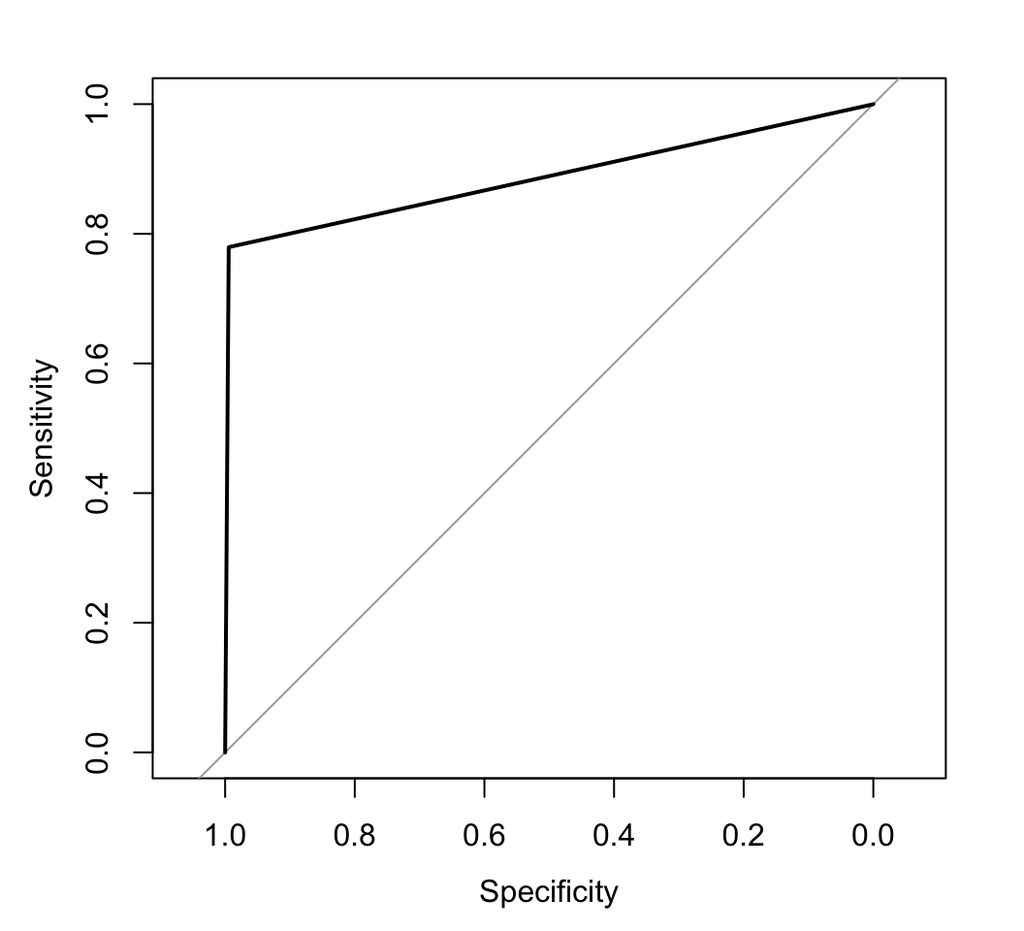

```r
plot(rocRFHoldOut)
```

```r
#performance table values
auc(rocRFHoldOut)
```

```
#> Area under the curve: 0.8869
```

```r
coords(rocRFHoldOut,'best', ret = 'threshold')
```

```
#>   threshold
#> 1       1.5
```

```r
coords(rocRFHoldOut,'best', ret = 'accuracy')
```

```
#>            accuracy
#> threshold 0.9923316
```

```r
coords(rocRFHoldOut,'best', ret = 'tpr')
```

```
#>                tpr
#> threshold 0.779404
```

```r
coords(rocRFHoldOut,'best', ret = 'fpr')
```

```
#>                  fpr
#> threshold 0.00564307
```

```r
coords(rocRFHoldOut,'best', ret = 'precision')
```

```
#>           precision
#> threshold 0.5678048
```

## 7.7 SVM

```r
#predict
ypredHoldOut <- predict(bestmod,HoldOutData,decision.values = TRUE)
fittedHoldOut <- attributes(ypredHoldOut)$decision.values
#confusion matrix
confusionMatrix(data = ypredHoldOut, reference = HoldOutData$BlueTarp)
```

```
#> Confusion Matrix and Statistics
#>
#>           Reference
#> Prediction   FALSE    TRUE
#>      FALSE 1972978   11055
#>      TRUE    16719    7871
#>
#>                Accuracy : 0.9862
#>                  95% CI : (0.986, 0.9863)
#>     No Information Rate : 0.9906
#>     P-Value [Acc > NIR] : 1
#>
#>                   Kappa : 0.3549
#>
#>  Mcnemar's Test P-Value : <2e-16
#>
#>             Sensitivity : 0.9916
#>             Specificity : 0.4159
#>          Pos Pred Value : 0.9944
#>          Neg Pred Value : 0.3201
#>              Prevalence : 0.9906
#>          Detection Rate : 0.9823
#>    Detection Prevalence : 0.9878
#>       Balanced Accuracy : 0.7037
#>
#>        'Positive' Class : FALSE
#>
```

```r
#roc
my_roc_svmHoldOut <- roc(HoldOutData$BlueTarp,fittedHoldOut)
```

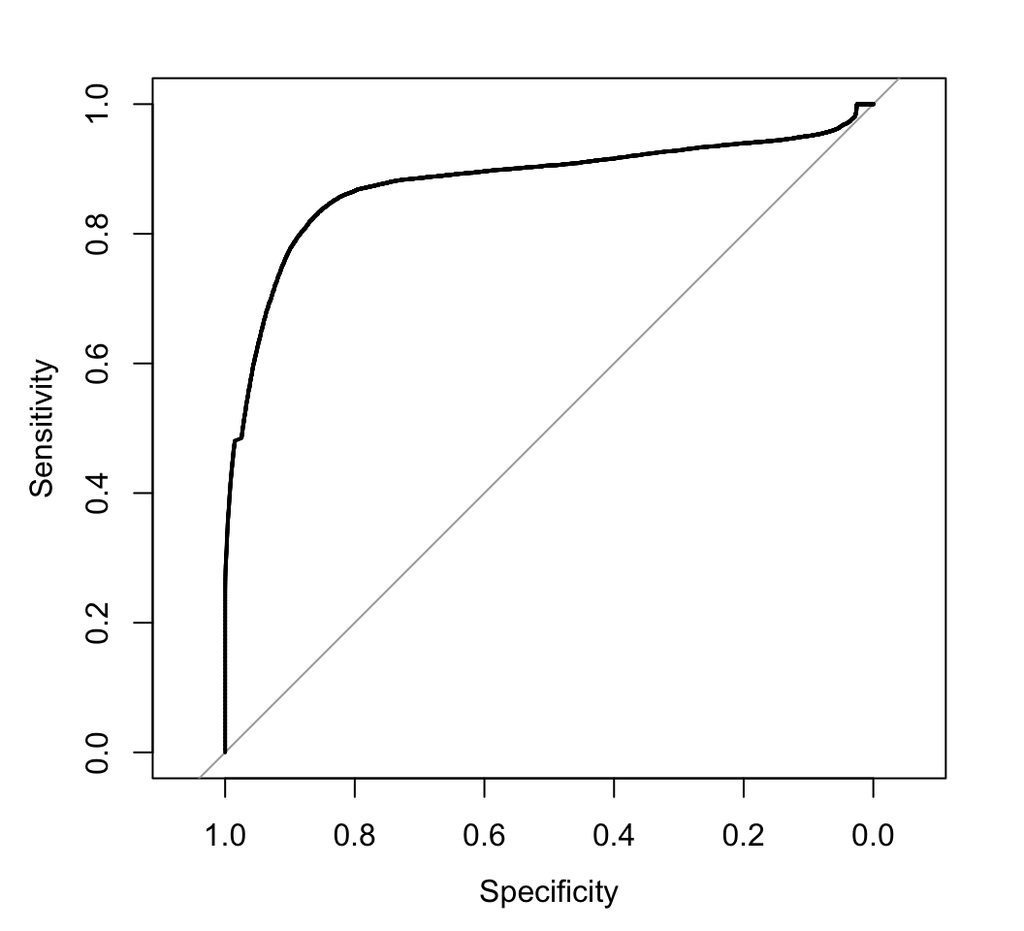

```r
plot(my_roc_svmHoldOut)
```

```r
#performance table values
auc(my_roc_svmHoldOut)
```

```
#> Area under the curve: 0.8789
```

```r
coords(my_roc_svmHoldOut,'best', ret = 'threshold')
```

```
#>   threshold
#> 1  7.132713
```

```r
coords(my_roc_svmHoldOut,'best', ret = 'accuracy')
```

```
#>            accuracy
#> threshold 0.8559944
```

```r
coords(my_roc_svmHoldOut,'best', ret = 'tpr')
```

```
#>                 tpr
#> threshold 0.8330339
```

```r
coords(my_roc_svmHoldOut,'best', ret = 'fpr')
```

```
#>                 fpr
#> threshold 0.1437872
```

```r
coords(my_roc_svmHoldOut,'best', ret = 'precision')
```

```
#>            precision
#> threshold 0.05222968
```

# 8 Results (Hold-Out)

```r
#glm
list.glmHoldOut <- list('n/a', as.numeric(my_roc_glmHoldOut$auc),as.numeric(coords(my_roc_glmHoldOut,'best',ret = 'threshold')),as.numeric(coords(my_roc_glmHoldOut,'best', ret = 'accuracy')),as.numeric(coords(my_roc_glmHoldOut,'best', ret = 'tpr')),as.numeric(coords(my_roc_glmHoldOut,'best', ret = 'fpr')),as.numeric(coords(my_roc_glmHoldOut,'best', ret = 'precision')))
df_glmHoldOut <- as.data.frame(list.glmHoldOut)
df_glmHoldOut <- data.frame(df_glmHoldOut, row.names = 'Log Reg')
colnames(df_glmHoldOut) <- c('Tuning','AUROC','Threshold','Accuracy','TPR','FPR',   'Precision')
df_glmHoldOut
```

```
#>         Tuning     AUROC Threshold  Accuracy       TPR         FPR Precision
#> Log Reg    n/a 0.9995454 0.6513031 0.9939829 0.9884815 0.005964727 0.6118524
```

```r
#lda
list.ldaHoldOut <- list(list('n/a', as.numeric(my_roc_ldaHoldOut$auc),as.numeric(coords(my_roc_ldaHoldOut,'best',ret = 'threshold')),as.numeric(coords(my_roc_ldaHoldOut,'best', ret = 'accuracy')),as.numeric(coords(my_roc_ldaHoldOut,'best', ret = 'tpr')),as.numeric(coords(my_roc_ldaHoldOut,'best', ret = 'fpr')),as.numeric(coords(my_roc_ldaHoldOut,'best', ret = 'precision'))))

df_ldaHoldOut <- as.data.frame(list.ldaHoldOut)
df_ldaHoldOut <- data.frame(df_ldaHoldOut,row.names = 'LDA')
colnames(df_ldaHoldOut) <- c('Tuning','AUROC','Threshold','Accuracy','TPR','FPR',   'Precision')
df_ldaHoldOut
```

```
#>     Tuning     AUROC Threshold  Accuracy       TPR        FPR Precision
#> LDA    n/a 0.9931744  1.689528 0.9603783 0.9883758 0.03988798 0.1907394
```

```r
#qda

list.qdaHoldOut <- list(list('n/a', as.numeric(my_roc_qdaHoldOut$auc),as.numeric(coords(my_roc_qdaHoldOut,'best',ret = 'threshold')),as.numeric(coords(my_roc_qdaHoldOut,'best', ret = 'accuracy')),as.numeric(coords(my_roc_qdaHoldOut,'best', ret = 'tpr')),as.numeric(coords(my_roc_qdaHoldOut,'best', ret = 'fpr')),as.numeric(coords(my_roc_qdaHoldOut,'best', ret = 'precision'))))

df_qdaHoldOut <- as.data.frame(list.qdaHoldOut)
df_qdaHoldOut <- data.frame(df_qdaHoldOut,row.names = 'QDA')
colnames(df_qdaHoldOut) <- c('Tuning','AUROC','Threshold','Accuracy','TPR','FPR',   'Precision')
df_qdaHoldOut
```

```
#>     Tuning     AUROC Threshold  Accuracy       TPR         FPR Precision
#> QDA    n/a 0.7740029       1.5 0.9923485 0.5514636 0.003457813 0.6027025
```

```r
#knn
list.knnHoldOut <- list(list(as.numeric(knnBestTune), as.numeric(my_roc_knnHoldOut$auc),as.numeric(coords(my_roc_knnHoldOut,'best',ret = 'threshold')),as.numeric(coords(my_roc_knnHoldOut,'best', ret = 'accuracy')),as.numeric(coords(my_roc_knnHoldOut,'best', ret = 'tpr')),as.numeric(coords(my_roc_knnHoldOut,'best', ret = 'fpr')),as.numeric(coords(my_roc_knnHoldOut,'best', ret = 'precision'))))

df_knnHoldOut <- as.data.frame(list.knnHoldOut)
df_knnHoldOut <- data.frame(df_knnHoldOut,row.names = 'KNN')
colnames(df_knnHoldOut) <- c('Tuning','AUROC','Threshold','Accuracy','TPR','FPR',   'Precision')
df_knnHoldOut
```

```
#>     Tuning     AUROC Threshold  Accuracy       TPR         FPR Precision
#> KNN      9 0.9388551       1.5 0.9923958 0.8842862 0.006575876 0.5612341
```

```r
#elastic

list.elasticHoldOut <- list(list(model.elastic$bestTune$lambda, as.numeric(my_roc_elasticHoldOut$auc),as.numeric(coords(my_roc_elasticHoldOut,'best',ret = 'threshold')),as.numeric(coords(my_roc_elasticHoldOut,'best', ret = 'accuracy')),as.numeric(coords(my_roc_elasticHoldOut,'best', ret = 'tpr')),as.numeric(coords(my_roc_elasticHoldOut,'best', ret = 'fpr')),as.numeric(coords(my_roc_elasticHoldOut,'best', ret = 'precision'))))

df_elasticHoldOut <- as.data.frame(list.elasticHoldOut)
df_elasticHoldOut <- data.frame(df_elasticHoldOut,row.names = 'Penalized Log Reg')
colnames(df_elasticHoldOut) <- c('Tuning','AUROC','Threshold','Accuracy','TPR','FPR',   'Precision')
df_elasticHoldOut
```

```
#>                         Tuning     AUROC Threshold Accuracy       TPR
#> Penalized Log Reg 1.901767e-05 0.9916696       1.5 0.993398 0.9899081
#>                           FPR Precision
#> Penalized Log Reg 0.006568839 0.5890583
```

```r
#random forest
list.rfHoldOut <- list(list(rfmodBestTune, as.numeric(rocRF$auc),as.numeric(coords(rocRFHoldOut,'best',ret = 'threshold')),as.numeric(coords(rocRFHoldOut,'best', ret = 'accuracy')),as.numeric(coords(rocRFHoldOut,'best', ret = 'tpr')),as.numeric(coords(rocRFHoldOut,'best', ret = 'fpr')),as.numeric(coords(rocRFHoldOut,'best', ret = 'precision'))))

df_rfHoldOut <- as.data.frame(list.rfHoldOut)
df_rfHoldOut <- data.frame(df_rfHoldOut,row.names = 'Random Forest')
colnames(df_rfHoldOut) <- c('Tuning','AUROC','Threshold','Accuracy','TPR','FPR',    'Precision')
df_rfHoldOut
```

```
#>               Tuning     AUROC Threshold  Accuracy      TPR        FPR
#> Random Forest      2 0.9722111       1.5 0.9923316 0.779404 0.00564307
#>               Precision
#> Random Forest 0.5678048
```

```r
#svm
list.svmCostHoldOut <- list(list(svmRadialBestTuneCost, as.numeric(my_roc_svmHoldOut$auc),as.numeric(coords(my_roc_svmHoldOut,'best',ret = 'threshold')),as.numeric(coords(my_roc_svmHoldOut,'best', ret = 'accuracy')),as.numeric(coords(my_roc_svmHoldOut,'best', ret = 'tpr')),as.numeric(coords(my_roc_svmHoldOut,'best', ret = 'fpr')),as.numeric(coords(my_roc_svmHoldOut,'best', ret = 'precision'))))

df_svmCostHoldOut <- as.data.frame(list.svmCostHoldOut)
df_svmCostHoldOut <- data.frame(df_svmCostHoldOut,row.names = 'Support Vector Machine (Best Cost Parameter')
colnames(df_svmCostHoldOut) <- c('Tuning','AUROC','Threshold','Accuracy','TPR','FPR',   'Precision')
df_svmCostHoldOut
```

```
#>                                             Tuning     AUROC Threshold
#> Support Vector Machine (Best Cost Parameter   1000 0.8788921  7.132713
#>                                              Accuracy       TPR       FPR
#> Support Vector Machine (Best Cost Parameter 0.8559944 0.8330339 0.1437872
#>                                              Precision
#> Support Vector Machine (Best Cost Parameter 0.05222968
```

**Hold-Out Performance Table Here**

```r
#Perf Table Hold Out

HoldOutPerfTable <- rbind(df_glmHoldOut,df_ldaHoldOut,df_qdaHoldOut,df_knnHoldOut,df_elasticHoldOut,df_rfHoldOut,df_svmCostHoldOut)
colnames(HoldOutPerfTable) <- c('Tuning','AUROC','Threshold','Accuracy','TPR','FPR',    'Precision')

HoldOutPerfTable
```

```
#>                                                           Tuning     AUROC
#> Log Reg                                                      n/a 0.9995454
#> LDA                                                          n/a 0.9931744
#> QDA                                                          n/a 0.7740029
#> KNN                                                            9 0.9388551
#> Penalized Log Reg                           1.90176708411387e-05 0.9916696
#> Random Forest                                                  2 0.9722111
#> Support Vector Machine (Best Cost Parameter                 1000 0.8788921
#>                                             Threshold  Accuracy       TPR
#> Log Reg                                     0.6513031 0.9939829 0.9884815
#> LDA                                         1.6895282 0.9603783 0.9883758
#> QDA                                         1.5000000 0.9923485 0.5514636
#> KNN                                         1.5000000 0.9923958 0.8842862
#> Penalized Log Reg                           1.5000000 0.9933980 0.9899081
#> Random Forest                               1.5000000 0.9923316 0.7794040
#> Support Vector Machine (Best Cost Parameter 7.1327126 0.8559944 0.8330339
#>                                                     FPR  Precision
#> Log Reg                                     0.005964727 0.61185243
#> LDA                                         0.039887983 0.19073936
#> QDA                                         0.003457813 0.60270255
#> KNN                                         0.006575876 0.56123407
#> Penalized Log Reg                           0.006568839 0.58905832
#> Random Forest                               0.005643070 0.56780477
#> Support Vector Machine (Best Cost Parameter 0.143787220 0.05222968
```

# 9 Final Conclusions

### 9.0.2 Conclusion #2

A discussion or analysis justifying why your findings above are compatible or reconcilable. The findings presented in this analysis are accurate throughout since we were able to create and train our model in part 1 and then test it using a split data set. We then saw that the models performed pretty well on the Hold Out data set which was not given until our models were created. This allowed us to use our models on a new data set and see how well they truly perform. The models were able to be used throughout the analysis since we set seeds at the start which allows us to reproduce our models at any given point. The models were compatible with the new data set after we did some data cleaning on the Hold Out data set.

### 9.0.4 Conclusion #4

A discussion of the relevance of the metrics calculated in the tables to this application context. The metrics calculated are relevant to this problem because we are trying to see how well our model predicts whether or not a blue tarp is present based on the predictors, Red, Green and Blue. The metrics we looked at gave us insight on how well the model performed through cross-validation on the data set we split into train and test as well as on a completely separate test set that we did not have access to previously. I focused mostly on Accuracy and TPR as the metrics to help evaluate model performance. I felt that these two metrics provided the best insight into model evaluation.

### 9.0.5 Conclusion #5

One thing that I could do different that may improve results is to use a multinomial approach instead of binomial. I set my factor to a Boolean. It was either Blue Tarp or not Blue Tarp, even though the original data set had more than just Blue Tarp as a category. I think that this may help improve the overall prediction since it would be more representative of the real world. I think that the multinomial approach would work better than binomial.